# Module 66

#### Contrast SVE:

Signed variance explained (SVE) provides an indication of how similar a set of fold changes are to a gene module’s weight vector. An SVE value of 0.3, for example, indicates that 30% of the variance explained by the entire module set is accounted for by the module in question. Shown here are the SVE values for this module across a compendium of fold changes (contrasts). Extreme SVE values (e.g., > 0.05) indicate that those contrasts specifically induce (orange dots) or specifically repress (blue dots) this module. Examining the experimental conditions being compared in such contrasts (see tables below the figure) may provide insight into the gene module’s function.

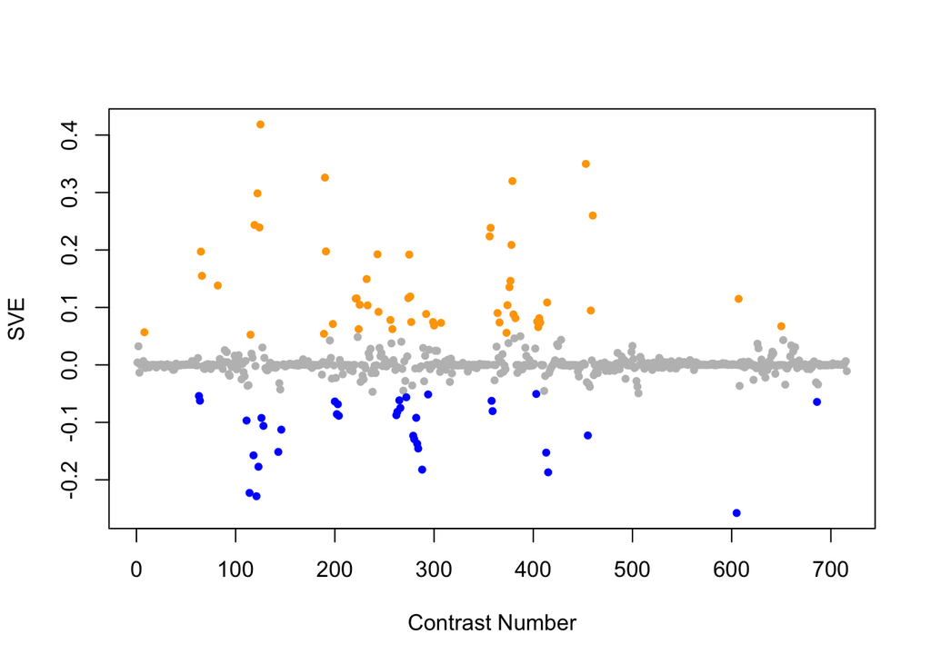

Positive SVE Contrasts:

|  | Contrast.Num | SVE | GEO.GSE | Cond.1 | Cond.2 | Mutation |
| --- | --- | --- | --- | --- | --- | --- |
| GSE54024.s1t1.vs.s2t1 | 125 | 0.42 | GSE54024 | Wild type young adults, biological rep 1 | Wild type young adults treated with 0.1mM paraquat, biological rep 1 |  |
| GSE25513.s3t1.vs.s0t1 | 453 | 0.35 | GSE25513 | aak-2 o/e (1) | WT (1) | aak-2 |
| GSE46291.s1t2.vs.s1t1 | 190 | 0.33 | GSE46291 | L4_rep1 | L3_rep1 |  |
| GSE34471.s1t2.vs.s0t2 | 379 | 0.32 | GSE34471 | 20uM-Exp1 | 20uM-Con-1 | hrg-2 |
| GSE54024.s1t1.vs.s4t1 | 122 | 0.30 | GSE54024 | Wild type young adults, biological rep 1 | isp-1(qm150) young adults, biological rep 1 | isp-1 |
| GSE23843C.s1t1.vs.s0t1 | 460 | 0.26 | GSE23843 | gld-2(RNAi), biological replicate 1 | wild-type total RNA, biological replicate 1 | gld-2 |
| GSE54024.s1t1.vs.s6t1 | 119 | 0.24 | GSE54024 | Wild type young adults, biological rep 1 | isp-1(qm150) ced-4(n1162) double mutant young adults, biological rep 1 | isp-1;ced-4 |
| GSE54024.s1t1.vs.s3t1 | 124 | 0.24 | GSE54024 | Wild type young adults, biological rep 1 | nuo-6(qm200) young adults, biological rep 1 | nuo-6 |
| GSE38196.s1t2.vs.s0t2 | 357 | 0.24 | GSE38196 | atfs-1(tm4525)-treated, biological rep1 | wild-type-treated, biological rep1 | afts-1 |
| GSE38196.s1t1.vs.s0t1 | 356 | 0.22 | GSE38196 | atfs-1(tm4525)-control, biological rep1 | wild-type-control, biological rep1 | afts-1 |
| GSE35354B.s1t4.vs.s1t1 | 378 | 0.21 | GSE35354 | TA300_rep1 | TA Control_rep1 |  |
| GSE46291.s2t2.vs.s2t1 | 191 | 0.20 | GSE46291 | L4-lethargus_rep1 | L3-lethargus_rep1 |  |
| GSE8659.s2t1.vs.s1t1 | 65 | 0.20 | GSE8659 | strain GR1373 replicate 1 | N2 replicate 1 | eri-1 |
| GSE42592C.s0t2.vs.s0t1 | 243 | 0.19 | GSE42592 | mercury_control_expose-4h_rep1 | mercury_control_expose-0h_rep1 |  |
| GSE41366B.s2t2.vs.s0t2 | 275 | 0.19 | GSE41366 | high_DDVP-8h_expose-20h_harvest-rep1 | control-8h_expose-20h_harvest-rep1 |  |
| GSE8659.s3t1.vs.s1t1 | 66 | 0.15 | GSE8659 | strain NL 2099 replicate 2 | N2 replicate 1 | rrf-3 |
| GSE42592B.s0t2.vs.s0t1 | 232 | 0.15 | GSE42592 | cadmium_control_expose-4h_rep1 | cadmium_control_expose-0h_rep1 |  |
| GSE35354B.s1t3.vs.s1t1 | 377 | 0.15 | GSE35354 | TA200_rep1 | TA Control_rep1 |  |
| GSE7354.s2t1.vs.s1t1 | 82 | 0.14 | GSE7354 | whole animal, nucleus accumbens: Extract1_le1 | whole animal, nucleus accumbens: Extract-Control_le1 |  |
| GSE35354B.s1t2.vs.s1t1 | 376 | 0.14 | GSE35354 | TA100_rep1 | TA Control_rep1 |  |
| GSE41366B.s1t2.vs.s0t2 | 276 | 0.12 | GSE41366 | low_DDVP-8h_expose-20h_harvest-rep1 | control-8h_expose-20h_harvest-rep1 |  |
| GSE41366B.s1t1.vs.s0t1 | 274 | 0.12 | GSE41366 | low_DDVP-8h_expose-14h_harvest-rep1 | control-8h_expose-14h_harvest-rep1 |  |
| GSE42592A.s0t3.vs.s0t1 | 222 | 0.12 | GSE42592 | acrylamide_control_expose-8h_rep1 | acrylamide_control_expose-0h_rep1 |  |
| GSE42592A.s0t2.vs.s0t1 | 221 | 0.12 | GSE42592 | acrylamide_control_expose-4h_rep1 | acrylamide_control_expose-0h_rep1 |  |
| GSE21784.s1t1.vs.s2t1 | 607 | 0.11 | GSE21784 | L4 larvae, biological rep1 | day 6 adults, biological rep 1 |  |
| GSE29951.s1t1.vs.s0t1 | 414 | 0.11 | GSE29951 | C.elegans MT KO mtl-1,mtl-2(zs1), raised in the absence of Cd, rep1 | C.elegans wild type raised in the absence of Cd, rep1 | mtl-1;mtl-2 |
| GSE42592A.s2t3.vs.s2t2 | 225 | 0.10 | GSE42592 | acrylamide_mid_expose-8h_rep1 | acrylamide_mid_expose-4h_rep1 |  |
| GSE35354A.s1t4.vs.s1t1 | 374 | 0.10 | GSE35354 | Q200_rep1 | Q control_rep1 |  |
| GSE42592B.s0t3.vs.s0t1 | 233 | 0.10 | GSE42592 | cadmium_control_expose-8h_rep1 | cadmium_control_expose-0h_rep1 |  |
| GSE23843A.s1t1.vs.s0t1 | 458 | 0.09 | GSE23843 | GLD-2 gld-2(RNAi)-IP, biological replicate 1 | GLD-2 wt-IP, biological replicate 1 |  |
| GSE42592C.s0t3.vs.s0t1 | 244 | 0.09 | GSE42592 | mercury_control_expose-8h_rep1 | mercury_control_expose-0h_rep1 |  |
| GSE36358.s1t1.vs.s0t1 | 364 | 0.09 | GSE36358 | Ground Control (operation site) | Ground Control (Tsukuba space center) |  |
| GSE41366C.s1t2.vs.s0t2 | 292 | 0.09 | GSE41366 | low_DDVP-continuous_expose-8h_harvest-rep1 | control-continuous_expose-2h_harvest-rep1 |  |
| GSE34471.s1t1.vs.s0t1 | 380 | 0.09 | GSE34471 | 4uM-Exp1 | 4uM-Con-1 | hrg-2 |
| GSE34471.s1t2.vs.s1t1 | 382 | 0.08 | GSE34471 | 20uM-Exp1 | 4uM-Exp1 |  |
| GSE30505.s2t1.vs.s3t1 | 406 | 0.08 | GSE30505 | L3 N2 (WT) ash-2 #1 | L3 glp-1 E.V. #1 | ash-2(RNAi) vs. glp-1 |
| GSE41366A.s2t2.vs.s0t2 | 256 | 0.08 | GSE41366 | high_DDVP-2h_expose-14h_harvest-rep1 | control-2h_expose-14h_harvest-rep1 |  |
| GSE30505.s2t1.vs.s4t1 | 404 | 0.08 | GSE30505 | L3 N2 (WT) ash-2 #1 | L3 glp-1 ash-2 #1 | glp-1 |
| GSE41366C.s0t3.vs.s0t1 | 299 | 0.07 | GSE41366 | control-continuous_expose-8h_harvest-rep1 | control-continuous_expose-0h_harvest-rep2 |  |
| GSE41366B.s2t3.vs.s0t3 | 277 | 0.07 | GSE41366 | high_DDVP-8h_expose-26h_harvest-rep1 | control-8h_expose-26h_harvest-rep1 |  |
| GSE36358.s4t1.vs.s0t1 | 366 | 0.07 | GSE36358 | Space Flight | Ground Control (Tsukuba space center) |  |
| GSE30505.s1t1.vs.s3t1 | 407 | 0.07 | GSE30505 | L3 N2 (WT) E.V. #1 | L3 glp-1 E.V. #1 | glp-1 |
| GSE41366C.s1t2.vs.s1t1 | 307 | 0.07 | GSE41366 | low_DDVP-continuous_expose-8h_harvest-rep1 | low_DDVP-continuous_expose-2h_harvest-rep1 |  |
| GSE43959.s3t2.vs.s4t2 | 198 | 0.07 | GSE43959 | N2 gravid adult on Comamonas DA1877 rep 1 | N2 gravid adult on 1:1000 Comamonas DA1877 rep 1 |  |
| GSE41366C.s2t3.vs.s2t1 | 300 | 0.07 | GSE41366 | high_DDVP-continuous_expose-14h_harvest-rep1 | high_DDVP-continuous_expose-2h_harvest-rep1 |  |
| GSE16405.s3t1.vs.s1t1 | 650 | 0.07 | GSE16405 | nth-1;xpa-1_1 | N2_1 | nth-1;xpa-1 |
| GSE30505.s1t1.vs.s4t1 | 405 | 0.07 | GSE30505 | L3 N2 (WT) E.V. #1 | L3 glp-1 ash-2 #1 | glp-1 |
| GSE41366A.s2t3.vs.s0t3 | 258 | 0.06 | GSE41366 | high_DDVP-2h_expose-20h_harvest-rep1 | control-2h_expose-20h_harvest-rep1 |  |
| GSE42592A.s1t3.vs.s1t2 | 224 | 0.06 | GSE42592 | acrylamide_low_expose-8h_rep1 | acrylamide_low_expose-4h_rep1 |  |
| GSE9897B.s5t1.vs.s0t1 | 8 | 0.06 | GSE9897 | Complex I RNAi Mutant 5 | Wildtype (control for RNAi) | D2030.4 |
| GSE35354A.s1t3.vs.s1t1 | 373 | 0.06 | GSE35354 | Q100_rep1 | Q control_rep1 |  |
| GSE46291.s1t3.vs.s1t1 | 189 | 0.05 | GSE46291 | Adult_rep1 | L3_rep1 |  |
| GSE54024.s1t1.vs.s5t1 | 115 | 0.05 | GSE54024 | Wild type young adults, biological rep 1 | ced-4(n1162) young adults, biological rep 1 | ced-4 |

Negative SVE Contrasts:

|  | Contrast.Num | SVE | GEO.GSE | Cond.1 | Cond.2 | Mutation |
| --- | --- | --- | --- | --- | --- | --- |
| GSE21784.s2t1.vs.s3t1 | 605 | -0.26 | GSE21784 | day 6 adults, biological rep 1 | day 15 adults, biological rep 1 |  |
| GSE54024.s2t1.vs.s4t1 | 121 | -0.23 | GSE54024 | Wild type young adults treated with 0.1mM paraquat, biological rep 1 | isp-1(qm150) young adults, biological rep 1 |  |
| GSE54024.s2t1.vs.s5t1 | 114 | -0.22 | GSE54024 | Wild type young adults treated with 0.1mM paraquat, biological rep 1 | ced-4(n1162) young adults, biological rep 1 |  |
| GSE29951.s1t2.vs.s1t1 | 415 | -0.19 | GSE29951 | C.elegans MT KO mtl-1,mtl-2(zs1) raised in the presence of Cd, rep1 | C.elegans MT KO mtl-1,mtl-2(zs1), raised in the absence of Cd, rep1 | mtl-1;mtl-2 |
| GSE41366C.s1t4.vs.s0t4 | 288 | -0.18 | GSE41366 | low_DDVP-continuous_expose-20h_harvest-rep1 | control-continuous_expose-14h_harvest-rep1 |  |
| GSE54024.s2t1.vs.s3t1 | 123 | -0.18 | GSE54024 | Wild type young adults treated with 0.1mM paraquat, biological rep 1 | nuo-6(qm200) young adults, biological rep 1 |  |
| GSE54024.s2t1.vs.s6t1 | 118 | -0.16 | GSE54024 | Wild type young adults treated with 0.1mM paraquat, biological rep 1 | isp-1(qm150) ced-4(n1162) double mutant young adults, biological rep 1 |  |
| GSE29951.s1t2.vs.s0t2 | 413 | -0.15 | GSE29951 | C.elegans MT KO mtl-1,mtl-2(zs1) raised in the presence of Cd, rep1 | C.elegans wild type raised in the presence of Cd, rep1 | mtl-1;mtl-2 |
| GSE50513.s3t1.vs.s1t1 | 143 | -0.15 | GSE50513 | zip-2 OP50 - rep 1 | L4440 OP50 - rep 1 | zip-2 |
| GSE41366B.s1t3.vs.s1t1 | 284 | -0.15 | GSE41366 | low_DDVP-8h_expose-26h_harvest-rep1 | low_DDVP-8h_expose-14h_harvest-rep1 |  |
| GSE41366B.s1t2.vs.s1t1 | 283 | -0.14 | GSE41366 | low_DDVP-8h_expose-20h_harvest-rep1 | low_DDVP-8h_expose-14h_harvest-rep1 |  |
| GSE41366B.s0t3.vs.s0t1 | 280 | -0.13 | GSE41366 | control-8h_expose-26h_harvest-rep1 | control-8h_expose-14h_harvest-rep1 |  |
| GSE41366B.s0t2.vs.s0t1 | 279 | -0.12 | GSE41366 | control-8h_expose-20h_harvest-rep1 | control-8h_expose-14h_harvest-rep1 |  |
| GSE25513.s1t1.vs.s0t1 | 455 | -0.12 | GSE25513 | tax-6 null (1) | WT (1) | tax-6 |
| GSE50513.s4t1.vs.s2t1 | 146 | -0.11 | GSE50513 | zip-2 PA14 - rep 1 | L4440 PA14 - rep 1 | zip-2 |
| GSE54011.s3t1.vs.s0t1 | 128 | -0.11 | GSE54011 | Ce 0.2 mM Se | Ce 0 mM Se |  |
| GSE54024.s6t1.vs.s5t1 | 111 | -0.10 | GSE54024 | isp-1(qm150) ced-4(n1162) double mutant young adults, biological rep 1 | ced-4(n1162) young adults, biological rep 1 | isp-1 |
| GSE54011.s1t1.vs.s0t1 | 126 | -0.09 | GSE54011 | Ce 0.05 mM Se | Ce 0 mM Se |  |
| GSE41366B.s2t3.vs.s2t1 | 282 | -0.09 | GSE41366 | high_DDVP-8h_expose-26h_harvest-rep1 | high_DDVP-8h_expose-14h_harvest-rep1 |  |
| GSE43952.s2t1.vs.s0t1 | 204 | -0.09 | GSE43952 | pcca-1(ok2282) fed Comamonas DA1877 rep1 | N2 gravid adult fed Comamonas DA1877 rep 1 | pcca-1 |
| GSE41366A.s2t1.vs.s0t1 | 262 | -0.09 | GSE41366 | high_DDVP-2h_expose-8h_harvest-rep1 | control-2h_expose-8h_harvest-rep1 |  |
| GSE43959.s1t2.vs.s1t1 | 202 | -0.09 | GSE43959 | N2 gravid adult on E. coli OP50 rep 1 | N2 young adult on E. coli OP50 rep 1 |  |
| GSE41366A.s1t1.vs.s0t1 | 263 | -0.08 | GSE41366 | low_DDVP-2h_expose-8h_harvest-rep1 | control-2h_expose-8h_harvest-rep1 |  |
| GSE38196.s0t2.vs.s0t1 | 359 | -0.08 | GSE38196 | wild-type-treated, biological rep1 | wild-type-control, biological rep1 | spg-7(RNAi) |
| GSE41366A.s0t4.vs.s0t1 | 266 | -0.07 | GSE41366 | control-2h_expose-26h_harvest-rep1 | control-2h_expose-8h_harvest-rep1 |  |
| GSE43952.s1t1.vs.s0t1 | 203 | -0.07 | GSE43952 | metr-1(ok521) fed Comamonas DA1877 rep 1 | N2 gravid adult fed Comamonas DA1877 rep 1 | metr-1 |
| GSE12298C.s1t1.vs.s0t1 | 686 | -0.06 | GSE12298 | mefloquine_low_dose-rep1 | mefloquine_control-rep1 |  |
| GSE43959.s1t2.vs.s3t2 | 200 | -0.06 | GSE43959 | N2 gravid adult on E. coli OP50 rep 1 | N2 gravid adult on Comamonas DA1877 rep 1 |  |
| GSE38196.s1t2.vs.s1t1 | 358 | -0.06 | GSE38196 | atfs-1(tm4525)-treated, biological rep1 | atfs-1(tm4525)-control, biological rep1 | spg-7(RNAi) |
| GSE8696.s3t1.vs.s1t1 | 64 | -0.06 | GSE8696 | 500 uM hemin (500A) | 4 uM hemin (4A) |  |
| GSE41366A.s0t3.vs.s0t1 | 265 | -0.06 | GSE41366 | control-2h_expose-20h_harvest-rep1 | control-2h_expose-8h_harvest-rep1 |  |
| GSE41366A.s1t4.vs.s1t1 | 272 | -0.06 | GSE41366 | low_DDVP-2h_expose-26h_harvest-rep1 | low_DDVP-2h_expose-8h_harvest-rep1 |  |
| GSE8696.s3t1.vs.s2t1 | 63 | -0.05 | GSE8696 | 500 uM hemin (500A) | 20 uM hemin (20A) |  |
| GSE41366C.s1t3.vs.s0t3 | 294 | -0.05 | GSE41366 | low_DDVP-continuous_expose-14h_harvest-rep1 | control-continuous_expose-8h_harvest-rep1 |  |
| GSE30505.s3t1.vs.s4t1 | 403 | -0.05 | GSE30505 | L3 glp-1 E.V. #1 | L3 glp-1 ash-2 #1 | ash-2 |

$~$

#### Contrast SVE, Up-Regulated Genes Only:

Calculating SVE for up-regulated and down-regulated genes separately may be more informative in many cases than projecting the up- and down- gene sets together. This is due to the fact that the weight distribution of many modules is highly skewed, indicating that only one of the hemi-modules may be biologically meaningful (i.e., a set of genes are strongly correlated by only a few genes (or none) are strongly anti-correlated to that set.)

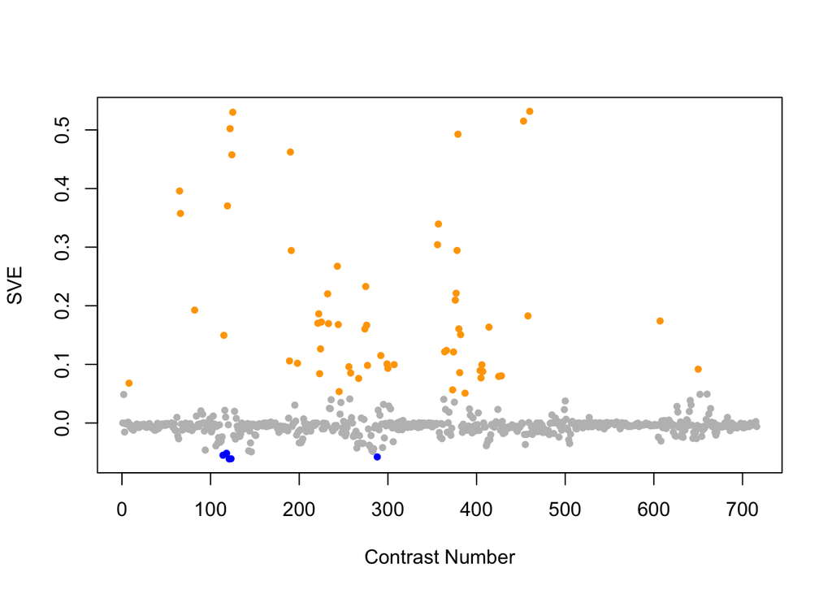

Positive SVE Contrasts:

|  | Contrast.Num | SVE | GEO.GSE | Cond.1 | Cond.2 | Mutation |
| --- | --- | --- | --- | --- | --- | --- |
| GSE23843C.s1t1.vs.s0t1 | 460 | 0.53 | GSE23843 | gld-2(RNAi), biological replicate 1 | wild-type total RNA, biological replicate 1 | gld-2 |
| GSE54024.s1t1.vs.s2t1 | 125 | 0.53 | GSE54024 | Wild type young adults, biological rep 1 | Wild type young adults treated with 0.1mM paraquat, biological rep 1 |  |
| GSE25513.s3t1.vs.s0t1 | 453 | 0.52 | GSE25513 | aak-2 o/e (1) | WT (1) | aak-2 |
| GSE54024.s1t1.vs.s4t1 | 122 | 0.50 | GSE54024 | Wild type young adults, biological rep 1 | isp-1(qm150) young adults, biological rep 1 | isp-1 |
| GSE34471.s1t2.vs.s0t2 | 379 | 0.49 | GSE34471 | 20uM-Exp1 | 20uM-Con-1 | hrg-2 |
| GSE46291.s1t2.vs.s1t1 | 190 | 0.46 | GSE46291 | L4_rep1 | L3_rep1 |  |
| GSE54024.s1t1.vs.s3t1 | 124 | 0.46 | GSE54024 | Wild type young adults, biological rep 1 | nuo-6(qm200) young adults, biological rep 1 | nuo-6 |
| GSE8659.s2t1.vs.s1t1 | 65 | 0.40 | GSE8659 | strain GR1373 replicate 1 | N2 replicate 1 | eri-1 |
| GSE54024.s1t1.vs.s6t1 | 119 | 0.37 | GSE54024 | Wild type young adults, biological rep 1 | isp-1(qm150) ced-4(n1162) double mutant young adults, biological rep 1 | isp-1;ced-4 |
| GSE8659.s3t1.vs.s1t1 | 66 | 0.36 | GSE8659 | strain NL 2099 replicate 2 | N2 replicate 1 | rrf-3 |
| GSE38196.s1t2.vs.s0t2 | 357 | 0.34 | GSE38196 | atfs-1(tm4525)-treated, biological rep1 | wild-type-treated, biological rep1 | afts-1 |
| GSE38196.s1t1.vs.s0t1 | 356 | 0.30 | GSE38196 | atfs-1(tm4525)-control, biological rep1 | wild-type-control, biological rep1 | afts-1 |
| GSE35354B.s1t4.vs.s1t1 | 378 | 0.29 | GSE35354 | TA300_rep1 | TA Control_rep1 |  |
| GSE46291.s2t2.vs.s2t1 | 191 | 0.29 | GSE46291 | L4-lethargus_rep1 | L3-lethargus_rep1 |  |
| GSE42592C.s0t2.vs.s0t1 | 243 | 0.27 | GSE42592 | mercury_control_expose-4h_rep1 | mercury_control_expose-0h_rep1 |  |
| GSE41366B.s2t2.vs.s0t2 | 275 | 0.23 | GSE41366 | high_DDVP-8h_expose-20h_harvest-rep1 | control-8h_expose-20h_harvest-rep1 |  |
| GSE35354B.s1t3.vs.s1t1 | 377 | 0.22 | GSE35354 | TA200_rep1 | TA Control_rep1 |  |
| GSE42592B.s0t2.vs.s0t1 | 232 | 0.22 | GSE42592 | cadmium_control_expose-4h_rep1 | cadmium_control_expose-0h_rep1 |  |
| GSE35354B.s1t2.vs.s1t1 | 376 | 0.21 | GSE35354 | TA100_rep1 | TA Control_rep1 |  |
| GSE7354.s2t1.vs.s1t1 | 82 | 0.19 | GSE7354 | whole animal, nucleus accumbens: Extract1_le1 | whole animal, nucleus accumbens: Extract-Control_le1 |  |
| GSE42592A.s0t3.vs.s0t1 | 222 | 0.19 | GSE42592 | acrylamide_control_expose-8h_rep1 | acrylamide_control_expose-0h_rep1 |  |
| GSE23843A.s1t1.vs.s0t1 | 458 | 0.18 | GSE23843 | GLD-2 gld-2(RNAi)-IP, biological replicate 1 | GLD-2 wt-IP, biological replicate 1 |  |
| GSE21784.s1t1.vs.s2t1 | 607 | 0.17 | GSE21784 | L4 larvae, biological rep1 | day 6 adults, biological rep 1 |  |
| GSE42592A.s2t3.vs.s2t2 | 225 | 0.17 | GSE42592 | acrylamide_mid_expose-8h_rep1 | acrylamide_mid_expose-4h_rep1 |  |
| GSE42592A.s0t2.vs.s0t1 | 221 | 0.17 | GSE42592 | acrylamide_control_expose-4h_rep1 | acrylamide_control_expose-0h_rep1 |  |
| GSE42592B.s0t3.vs.s0t1 | 233 | 0.17 | GSE42592 | cadmium_control_expose-8h_rep1 | cadmium_control_expose-0h_rep1 |  |
| GSE42592C.s0t3.vs.s0t1 | 244 | 0.17 | GSE42592 | mercury_control_expose-8h_rep1 | mercury_control_expose-0h_rep1 |  |
| GSE41366B.s1t2.vs.s0t2 | 276 | 0.17 | GSE41366 | low_DDVP-8h_expose-20h_harvest-rep1 | control-8h_expose-20h_harvest-rep1 |  |
| GSE29951.s1t1.vs.s0t1 | 414 | 0.16 | GSE29951 | C.elegans MT KO mtl-1,mtl-2(zs1), raised in the absence of Cd, rep1 | C.elegans wild type raised in the absence of Cd, rep1 | mtl-1;mtl-2 |
| GSE34471.s1t1.vs.s0t1 | 380 | 0.16 | GSE34471 | 4uM-Exp1 | 4uM-Con-1 | hrg-2 |
| GSE41366B.s1t1.vs.s0t1 | 274 | 0.16 | GSE41366 | low_DDVP-8h_expose-14h_harvest-rep1 | control-8h_expose-14h_harvest-rep1 |  |
| GSE34471.s1t2.vs.s1t1 | 382 | 0.15 | GSE34471 | 20uM-Exp1 | 4uM-Exp1 |  |
| GSE54024.s1t1.vs.s5t1 | 115 | 0.15 | GSE54024 | Wild type young adults, biological rep 1 | ced-4(n1162) young adults, biological rep 1 | ced-4 |
| GSE42592A.s1t3.vs.s1t2 | 224 | 0.13 | GSE42592 | acrylamide_low_expose-8h_rep1 | acrylamide_low_expose-4h_rep1 |  |
| GSE36358.s4t1.vs.s0t1 | 366 | 0.12 | GSE36358 | Space Flight | Ground Control (Tsukuba space center) |  |
| GSE36358.s1t1.vs.s0t1 | 364 | 0.12 | GSE36358 | Ground Control (operation site) | Ground Control (Tsukuba space center) |  |
| GSE35354A.s1t4.vs.s1t1 | 374 | 0.12 | GSE35354 | Q200_rep1 | Q control_rep1 |  |
| GSE41366C.s1t2.vs.s0t2 | 292 | 0.11 | GSE41366 | low_DDVP-continuous_expose-8h_harvest-rep1 | control-continuous_expose-2h_harvest-rep1 |  |
| GSE46291.s1t3.vs.s1t1 | 189 | 0.11 | GSE46291 | Adult_rep1 | L3_rep1 |  |
| GSE43959.s3t2.vs.s4t2 | 198 | 0.10 | GSE43959 | N2 gravid adult on Comamonas DA1877 rep 1 | N2 gravid adult on 1:1000 Comamonas DA1877 rep 1 |  |
| GSE41366C.s0t3.vs.s0t1 | 299 | 0.10 | GSE41366 | control-continuous_expose-8h_harvest-rep1 | control-continuous_expose-0h_harvest-rep2 |  |
| GSE41366C.s1t2.vs.s1t1 | 307 | 0.10 | GSE41366 | low_DDVP-continuous_expose-8h_harvest-rep1 | low_DDVP-continuous_expose-2h_harvest-rep1 |  |
| GSE30505.s2t1.vs.s3t1 | 406 | 0.10 | GSE30505 | L3 N2 (WT) ash-2 #1 | L3 glp-1 E.V. #1 | ash-2(RNAi) vs. glp-1 |
| GSE41366B.s2t3.vs.s0t3 | 277 | 0.10 | GSE41366 | high_DDVP-8h_expose-26h_harvest-rep1 | control-8h_expose-26h_harvest-rep1 |  |
| GSE41366A.s2t2.vs.s0t2 | 256 | 0.10 | GSE41366 | high_DDVP-2h_expose-14h_harvest-rep1 | control-2h_expose-14h_harvest-rep1 |  |
| GSE41366C.s2t3.vs.s2t1 | 300 | 0.09 | GSE41366 | high_DDVP-continuous_expose-14h_harvest-rep1 | high_DDVP-continuous_expose-2h_harvest-rep1 |  |
| GSE16405.s3t1.vs.s1t1 | 650 | 0.09 | GSE16405 | nth-1;xpa-1_1 | N2_1 | nth-1;xpa-1 |
| GSE30505.s2t1.vs.s4t1 | 404 | 0.09 | GSE30505 | L3 N2 (WT) ash-2 #1 | L3 glp-1 ash-2 #1 | glp-1 |
| GSE30505.s1t1.vs.s3t1 | 407 | 0.09 | GSE30505 | L3 N2 (WT) E.V. #1 | L3 glp-1 E.V. #1 | glp-1 |
| GSE34471.s0t2.vs.s0t1 | 381 | 0.09 | GSE34471 | 20uM-Con-1 | 4uM-Con-1 |  |
| GSE41366A.s2t3.vs.s0t3 | 258 | 0.09 | GSE41366 | high_DDVP-2h_expose-20h_harvest-rep1 | control-2h_expose-20h_harvest-rep1 |  |
| GSE42592A.s3t3.vs.s3t2 | 223 | 0.08 | GSE42592 | acrylamide_high_expose-8h_rep1 | acrylamide_high_expose-4h_rep1 |  |
| GSE27677A.s3t1.vs.s0t1 | 428 | 0.08 | GSE27677 | daf-16, Fed , rep 1 | N2, Fed , rep 1 | daf-16 |
| GSE27677A.s3t2.vs.s0t2 | 425 | 0.08 | GSE27677 | daf-16, Fast , rep 1 | N2, Fast , rep 1 | daf-16 |
| GSE30505.s1t1.vs.s4t1 | 405 | 0.08 | GSE30505 | L3 N2 (WT) E.V. #1 | L3 glp-1 ash-2 #1 | glp-1 |
| GSE41366A.s2t2.vs.s2t1 | 267 | 0.08 | GSE41366 | high_DDVP-2h_expose-14h_harvest-rep1 | high_DDVP-2h_expose-8h_harvest-rep1 |  |
| GSE9897B.s5t1.vs.s0t1 | 8 | 0.07 | GSE9897 | Complex I RNAi Mutant 5 | Wildtype (control for RNAi) | D2030.4 |
| GSE35354A.s1t3.vs.s1t1 | 373 | 0.06 | GSE35354 | Q100_rep1 | Q control_rep1 |  |
| GSE42592C.s3t3.vs.s3t2 | 245 | 0.05 | GSE42592 | mercury_high_expose-8h_rep1 | mercury_high_expose-4h_rep1 |  |
| GSE34026.s1t1.vs.s0t1 | 387 | 0.05 | GSE34026 | N2 exposed to hemolysin mutant of E7946, biological rep1 | N2 exposed to OP50(E.coli), biological rep1 |  |

Negative SVE Contrasts:

|  | Contrast.Num | SVE | GEO.GSE | Cond.1 | Cond.2 | Mutation |
| --- | --- | --- | --- | --- | --- | --- |
| GSE54024.s2t1.vs.s4t1 | 121 | -0.06 | GSE54024 | Wild type young adults treated with 0.1mM paraquat, biological rep 1 | isp-1(qm150) young adults, biological rep 1 |  |
| GSE54024.s2t1.vs.s3t1 | 123 | -0.06 | GSE54024 | Wild type young adults treated with 0.1mM paraquat, biological rep 1 | nuo-6(qm200) young adults, biological rep 1 |  |
| GSE41366C.s1t4.vs.s0t4 | 288 | -0.06 | GSE41366 | low_DDVP-continuous_expose-20h_harvest-rep1 | control-continuous_expose-14h_harvest-rep1 |  |
| GSE54024.s2t1.vs.s5t1 | 114 | -0.05 | GSE54024 | Wild type young adults treated with 0.1mM paraquat, biological rep 1 | ced-4(n1162) young adults, biological rep 1 |  |
| GSE54024.s2t1.vs.s6t1 | 118 | -0.05 | GSE54024 | Wild type young adults treated with 0.1mM paraquat, biological rep 1 | isp-1(qm150) ced-4(n1162) double mutant young adults, biological rep 1 |  |

$~$

#### Contrast SVE, Down-Regulated Genes Only:

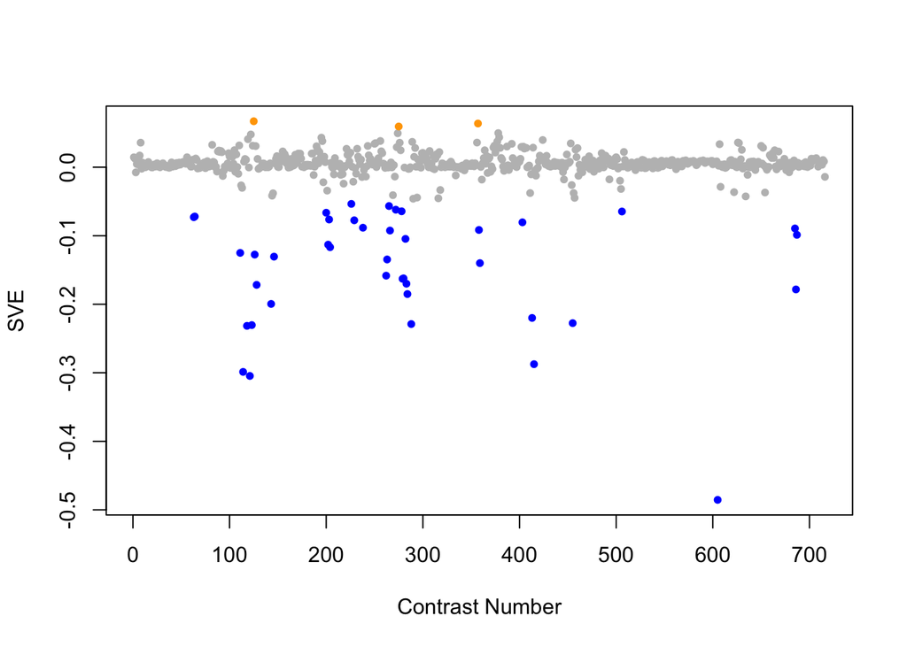

Positive SVE Contrasts:

[output not shown]

Negative SVE Contrasts:

|  | Contrast.Num | SVE | GEO.GSE | Cond.1 | Cond.2 | Mutation |
| --- | --- | --- | --- | --- | --- | --- |
| GSE21784.s2t1.vs.s3t1 | 605 | -0.49 | GSE21784 | day 6 adults, biological rep 1 | day 15 adults, biological rep 1 |  |
| GSE54024.s2t1.vs.s4t1 | 121 | -0.30 | GSE54024 | Wild type young adults treated with 0.1mM paraquat, biological rep 1 | isp-1(qm150) young adults, biological rep 1 |  |
| GSE54024.s2t1.vs.s5t1 | 114 | -0.30 | GSE54024 | Wild type young adults treated with 0.1mM paraquat, biological rep 1 | ced-4(n1162) young adults, biological rep 1 |  |
| GSE29951.s1t2.vs.s1t1 | 415 | -0.29 | GSE29951 | C.elegans MT KO mtl-1,mtl-2(zs1) raised in the presence of Cd, rep1 | C.elegans MT KO mtl-1,mtl-2(zs1), raised in the absence of Cd, rep1 | mtl-1;mtl-2 |
| GSE54024.s2t1.vs.s6t1 | 118 | -0.23 | GSE54024 | Wild type young adults treated with 0.1mM paraquat, biological rep 1 | isp-1(qm150) ced-4(n1162) double mutant young adults, biological rep 1 |  |
| GSE54024.s2t1.vs.s3t1 | 123 | -0.23 | GSE54024 | Wild type young adults treated with 0.1mM paraquat, biological rep 1 | nuo-6(qm200) young adults, biological rep 1 |  |
| GSE41366C.s1t4.vs.s0t4 | 288 | -0.23 | GSE41366 | low_DDVP-continuous_expose-20h_harvest-rep1 | control-continuous_expose-14h_harvest-rep1 |  |
| GSE25513.s1t1.vs.s0t1 | 455 | -0.23 | GSE25513 | tax-6 null (1) | WT (1) | tax-6 |
| GSE29951.s1t2.vs.s0t2 | 413 | -0.22 | GSE29951 | C.elegans MT KO mtl-1,mtl-2(zs1) raised in the presence of Cd, rep1 | C.elegans wild type raised in the presence of Cd, rep1 | mtl-1;mtl-2 |
| GSE50513.s3t1.vs.s1t1 | 143 | -0.20 | GSE50513 | zip-2 OP50 - rep 1 | L4440 OP50 - rep 1 | zip-2 |
| GSE41366B.s1t3.vs.s1t1 | 284 | -0.19 | GSE41366 | low_DDVP-8h_expose-26h_harvest-rep1 | low_DDVP-8h_expose-14h_harvest-rep1 |  |
| GSE12298C.s1t1.vs.s0t1 | 686 | -0.18 | GSE12298 | mefloquine_low_dose-rep1 | mefloquine_control-rep1 |  |
| GSE54011.s3t1.vs.s0t1 | 128 | -0.17 | GSE54011 | Ce 0.2 mM Se | Ce 0 mM Se |  |
| GSE41366B.s1t2.vs.s1t1 | 283 | -0.17 | GSE41366 | low_DDVP-8h_expose-20h_harvest-rep1 | low_DDVP-8h_expose-14h_harvest-rep1 |  |
| GSE41366B.s0t2.vs.s0t1 | 279 | -0.16 | GSE41366 | control-8h_expose-20h_harvest-rep1 | control-8h_expose-14h_harvest-rep1 |  |
| GSE41366B.s0t3.vs.s0t1 | 280 | -0.16 | GSE41366 | control-8h_expose-26h_harvest-rep1 | control-8h_expose-14h_harvest-rep1 |  |
| GSE41366A.s2t1.vs.s0t1 | 262 | -0.16 | GSE41366 | high_DDVP-2h_expose-8h_harvest-rep1 | control-2h_expose-8h_harvest-rep1 |  |
| GSE38196.s0t2.vs.s0t1 | 359 | -0.14 | GSE38196 | wild-type-treated, biological rep1 | wild-type-control, biological rep1 | spg-7(RNAi) |
| GSE41366A.s1t1.vs.s0t1 | 263 | -0.13 | GSE41366 | low_DDVP-2h_expose-8h_harvest-rep1 | control-2h_expose-8h_harvest-rep1 |  |
| GSE50513.s4t1.vs.s2t1 | 146 | -0.13 | GSE50513 | zip-2 PA14 - rep 1 | L4440 PA14 - rep 1 | zip-2 |
| GSE54011.s1t1.vs.s0t1 | 126 | -0.13 | GSE54011 | Ce 0.05 mM Se | Ce 0 mM Se |  |
| GSE54024.s6t1.vs.s5t1 | 111 | -0.12 | GSE54024 | isp-1(qm150) ced-4(n1162) double mutant young adults, biological rep 1 | ced-4(n1162) young adults, biological rep 1 | isp-1 |
| GSE43952.s2t1.vs.s0t1 | 204 | -0.12 | GSE43952 | pcca-1(ok2282) fed Comamonas DA1877 rep1 | N2 gravid adult fed Comamonas DA1877 rep 1 | pcca-1 |
| GSE43959.s1t2.vs.s1t1 | 202 | -0.11 | GSE43959 | N2 gravid adult on E. coli OP50 rep 1 | N2 young adult on E. coli OP50 rep 1 |  |
| GSE41366B.s2t3.vs.s2t1 | 282 | -0.10 | GSE41366 | high_DDVP-8h_expose-26h_harvest-rep1 | high_DDVP-8h_expose-14h_harvest-rep1 |  |
| GSE12298C.s2t1.vs.s0t1 | 687 | -0.10 | GSE12298 | mefloquine_mid_dose-rep1 | mefloquine_control-rep1 |  |
| GSE41366A.s0t4.vs.s0t1 | 266 | -0.09 | GSE41366 | control-2h_expose-26h_harvest-rep1 | control-2h_expose-8h_harvest-rep1 |  |
| GSE38196.s1t2.vs.s1t1 | 358 | -0.09 | GSE38196 | atfs-1(tm4525)-treated, biological rep1 | atfs-1(tm4525)-control, biological rep1 | spg-7(RNAi) |
| GSE12298C.s3t1.vs.s0t1 | 685 | -0.09 | GSE12298 | mefloquine_high_dose-rep1 | mefloquine_control-rep1 |  |
| GSE42592C.s1t2.vs.s0t2 | 238 | -0.09 | GSE42592 | mercury_low_expose-4h_rep1 | mercury_control_expose-4h_rep1 |  |
| GSE30505.s3t1.vs.s4t1 | 403 | -0.08 | GSE30505 | L3 glp-1 E.V. #1 | L3 glp-1 ash-2 #1 | ash-2 |
| GSE42592B.s3t3.vs.s0t3 | 229 | -0.08 | GSE42592 | cadmium_high_expose-8h_rep1 | cadmium_control_expose-8h_rep1 |  |
| GSE43952.s1t1.vs.s0t1 | 203 | -0.08 | GSE43952 | metr-1(ok521) fed Comamonas DA1877 rep 1 | N2 gravid adult fed Comamonas DA1877 rep 1 | metr-1 |
| GSE8696.s3t1.vs.s2t1 | 63 | -0.07 | GSE8696 | 500 uM hemin (500A) | 20 uM hemin (20A) |  |
| GSE8696.s3t1.vs.s1t1 | 64 | -0.07 | GSE8696 | 500 uM hemin (500A) | 4 uM hemin (4A) |  |
| GSE43959.s1t2.vs.s3t2 | 200 | -0.07 | GSE43959 | N2 gravid adult on E. coli OP50 rep 1 | N2 gravid adult on Comamonas DA1877 rep 1 |  |
| GSE2210.s1t1.vs.s0t1 | 506 | -0.06 | GSE2210 | tom-1(nu468) Sample 1 | Wild type Sample 1 | tom-1 |
| GSE41366B.s1t3.vs.s0t3 | 278 | -0.06 | GSE41366 | low_DDVP-8h_expose-26h_harvest-rep1 | control-8h_expose-26h_harvest-rep1 |  |
| GSE41366A.s1t4.vs.s1t1 | 272 | -0.06 | GSE41366 | low_DDVP-2h_expose-26h_harvest-rep1 | low_DDVP-2h_expose-8h_harvest-rep1 |  |
| GSE41366A.s0t3.vs.s0t1 | 265 | -0.06 | GSE41366 | control-2h_expose-20h_harvest-rep1 | control-2h_expose-8h_harvest-rep1 |  |
| GSE42592B.s3t2.vs.s0t2 | 226 | -0.05 | GSE42592 | cadmium_high_expose-4h_rep1 | cadmium_control_expose-4h_rep1 |  |

$~$

$~$

#### GO Term Enrichment:

This analysis tests each hemi-module for enrichment of specific GO terms. Only gene-level annotations (e.g., as would be found on the gene’s page in Wormbase) are tested - the hierarchical structure of the GO ontology is not taken into account.

*Note: At least the top two most enriched terms from each GO domain (BP/MF/CC) are shown, even when not statistically significant.*

##### Enriched GO terms: Hemi-module A

| ID | GO.Term | GO Domain | Raw p-value | Adj p-value |
| --- | --- | --- | --- | --- |
| [GO_0006470](http://amigo.geneontology.org/amigo/term/GO:0006470) | protein dephosphorylation | BP | 7.83e-53 | 2.85e-49 |
| [GO_0018105](http://amigo.geneontology.org/amigo/term/GO:0018105) | peptidyl-serine phosphorylation | BP | 3.51e-43 | 6.40e-40 |
| [GO_0006468](http://amigo.geneontology.org/amigo/term/GO:0006468) | protein phosphorylation | BP | 1.35e-40 | 1.64e-37 |
| [GO_0035335](http://amigo.geneontology.org/amigo/term/GO:0035335) | peptidyl-tyrosine dephosphorylation | BP | 8.93e-40 | 8.13e-37 |
| [GO_0016310](http://amigo.geneontology.org/amigo/term/GO:0016310) | phosphorylation | BP | 1.65e-37 | 1.20e-34 |
| [GO_0038083](http://amigo.geneontology.org/amigo/term/GO:0038083) | peptidyl-tyrosine autophosphorylation | BP | 2.23e-26 | 1.35e-23 |
| [GO_0042127](http://amigo.geneontology.org/amigo/term/GO:0042127) | regulation of cell proliferation | BP | 6.11e-24 | 3.18e-21 |
| [GO_0007169](http://amigo.geneontology.org/amigo/term/GO:0007169) | transmembrane receptor protein tyrosine kinase signaling pathway | BP | 9.89e-18 | 4.50e-15 |
| [GO_0016477](http://amigo.geneontology.org/amigo/term/GO:0016477) | cell migration | BP | 3.89e-15 | 1.57e-12 |
| [GO_0007286](http://amigo.geneontology.org/amigo/term/GO:0007286) | spermatid development | BP | 1.17e-09 | 4.26e-07 |
| [GO_0006355](http://amigo.geneontology.org/amigo/term/GO:0006355) | regulation of transcription, DNA-templated | BP | 1.59e-09 | 5.27e-07 |
| [GO_0007186](http://amigo.geneontology.org/amigo/term/GO:0007186) | G protein-coupled receptor signaling pathway | BP | 1.91e-09 | 5.81e-07 |
| [GO_0030154](http://amigo.geneontology.org/amigo/term/GO:0030154) | cell differentiation | BP | 5.33e-07 | 1.49e-04 |
| [GO_0009792](http://amigo.geneontology.org/amigo/term/GO:0009792) | embryo development ending in birth or egg hatching | BP | 1.10e-06 | 2.85e-04 |
| [GO_0007283](http://amigo.geneontology.org/amigo/term/GO:0007283) | spermatogenesis | BP | 2.45e-06 | 5.94e-04 |
| [GO_0002119](http://amigo.geneontology.org/amigo/term/GO:0002119) | nematode larval development | BP | 6.60e-05 | 1.50e-02 |
| [GO_0045087](http://amigo.geneontology.org/amigo/term/GO:0045087) | innate immune response | BP | 7.25e-05 | 1.55e-02 |
| [GO_0007165](http://amigo.geneontology.org/amigo/term/GO:0007165) | signal transduction | BP | 2.62e-04 | 5.29e-02 |
| [GO_0045944](http://amigo.geneontology.org/amigo/term/GO:0045944) | positive regulation of transcription by RNA polymerase II | BP | 3.21e-04 | 6.16e-02 |
| [GO_0007275](http://amigo.geneontology.org/amigo/term/GO:0007275) | multicellular organism development | BP | 4.15e-04 | 7.57e-02 |
| [GO_0007049](http://amigo.geneontology.org/amigo/term/GO:0007049) | cell cycle | BP | 5.43e-04 | 9.03e-02 |
| [GO_0055114](http://amigo.geneontology.org/amigo/term/GO:0055114) | oxidation-reduction process | BP | 5.45e-04 | 9.03e-02 |
| [GO_0004725](http://amigo.geneontology.org/amigo/term/GO:0004725) | protein tyrosine phosphatase activity | MF | 3.72e-42 | 7.11e-39 |
| [GO_0004672](http://amigo.geneontology.org/amigo/term/GO:0004672) | protein kinase activity | MF | 6.96e-42 | 7.11e-39 |
| [GO_0016301](http://amigo.geneontology.org/amigo/term/GO:0016301) | kinase activity | MF | 3.17e-38 | 2.16e-35 |
| [GO_0004715](http://amigo.geneontology.org/amigo/term/GO:0004715) | non-membrane spanning protein tyrosine kinase activity | MF | 3.43e-29 | 1.75e-26 |
| [GO_0004721](http://amigo.geneontology.org/amigo/term/GO:0004721) | phosphoprotein phosphatase activity | MF | 4.54e-29 | 1.85e-26 |
| [GO_0004674](http://amigo.geneontology.org/amigo/term/GO:0004674) | protein serine/threonine kinase activity | MF | 3.08e-27 | 1.05e-24 |
| [GO_0005524](http://amigo.geneontology.org/amigo/term/GO:0005524) | ATP binding | MF | 4.85e-21 | 1.42e-18 |
| [GO_0004713](http://amigo.geneontology.org/amigo/term/GO:0004713) | protein tyrosine kinase activity | MF | 1.01e-18 | 2.57e-16 |
| [GO_0005102](http://amigo.geneontology.org/amigo/term/GO:0005102) | signaling receptor binding | MF | 1.46e-17 | 3.32e-15 |
| [GO_0004722](http://amigo.geneontology.org/amigo/term/GO:0004722) | protein serine/threonine phosphatase activity | MF | 2.52e-17 | 5.15e-15 |
| [GO_0005515](http://amigo.geneontology.org/amigo/term/GO:0005515) | protein binding | MF | 3.91e-12 | 7.26e-10 |
| [GO_0003677](http://amigo.geneontology.org/amigo/term/GO:0003677) | DNA binding | MF | 4.24e-09 | 7.22e-07 |
| [GO_0003700](http://amigo.geneontology.org/amigo/term/GO:0003700) | DNA-binding transcription factor activity | MF | 2.38e-08 | 3.75e-06 |
| [GO_0016787](http://amigo.geneontology.org/amigo/term/GO:0016787) | hydrolase activity | MF | 1.04e-07 | 1.43e-05 |
| [GO_0046872](http://amigo.geneontology.org/amigo/term/GO:0046872) | metal ion binding | MF | 1.05e-07 | 1.43e-05 |
| [GO_0043565](http://amigo.geneontology.org/amigo/term/GO:0043565) | sequence-specific DNA binding | MF | 5.19e-07 | 6.63e-05 |
| [GO_0003723](http://amigo.geneontology.org/amigo/term/GO:0003723) | RNA binding | MF | 1.64e-06 | 1.97e-04 |
| [GO_0008270](http://amigo.geneontology.org/amigo/term/GO:0008270) | zinc ion binding | MF | 7.58e-06 | 8.60e-04 |
| [GO_0015075](http://amigo.geneontology.org/amigo/term/GO:0015075) | ion transmembrane transporter activity | MF | 1.28e-04 | 1.37e-02 |
| [GO_0004930](http://amigo.geneontology.org/amigo/term/GO:0004930) | G protein-coupled receptor activity | MF | 2.59e-04 | 2.53e-02 |
| [GO_0005328](http://amigo.geneontology.org/amigo/term/GO:0005328) | neurotransmitter:sodium symporter activity | MF | 2.60e-04 | 2.53e-02 |
| [GO_0000166](http://amigo.geneontology.org/amigo/term/GO:0000166) | nucleotide binding | MF | 2.79e-04 | 2.59e-02 |
| [GO_0004888](http://amigo.geneontology.org/amigo/term/GO:0004888) | transmembrane signaling receptor activity | MF | 3.73e-04 | 3.32e-02 |
| [GO_0000977](http://amigo.geneontology.org/amigo/term/GO:0000977) | RNA polymerase II regulatory region sequence-specific DNA binding | MF | 4.10e-04 | 3.49e-02 |
| [GO_0005332](http://amigo.geneontology.org/amigo/term/GO:0005332) | gamma-aminobutyric acid:sodium symporter activity | MF | 8.49e-04 | 6.67e-02 |
| [GO_0042165](http://amigo.geneontology.org/amigo/term/GO:0042165) | neurotransmitter binding | MF | 8.49e-04 | 6.67e-02 |
| [GO_0020037](http://amigo.geneontology.org/amigo/term/GO:0020037) | heme binding | MF | 1.32e-03 | 9.98e-02 |
| [GO_0031234](http://amigo.geneontology.org/amigo/term/GO:0031234) | extrinsic component of cytoplasmic side of plasma membrane | CC | 7.79e-25 | 7.23e-22 |
| [GO_0016021](http://amigo.geneontology.org/amigo/term/GO:0016021) | integral component of membrane | CC | 1.01e-04 | 3.49e-02 |
| [GO_0005829](http://amigo.geneontology.org/amigo/term/GO:0005829) | cytosol | CC | 1.13e-04 | 3.49e-02 |
| [GO_0005576](http://amigo.geneontology.org/amigo/term/GO:0005576) | extracellular region | CC | 2.16e-04 | 4.23e-02 |
| [GO_0005737](http://amigo.geneontology.org/amigo/term/GO:0005737) | cytoplasm | CC | 2.28e-04 | 4.23e-02 |
| [GO_0045202](http://amigo.geneontology.org/amigo/term/GO:0045202) | synapse | CC | 3.35e-04 | 5.18e-02 |
| [GO_0005887](http://amigo.geneontology.org/amigo/term/GO:0005887) | integral component of plasma membrane | CC | 4.82e-04 | 6.39e-02 |

##### Enriched GO terms: Hemi-module B

| ID | GO.Term | GO Domain | Raw p-value | Adj p-value |
| --- | --- | --- | --- | --- |
| [GO_0006515](http://amigo.geneontology.org/amigo/term/GO:0006515) | protein quality control for misfolded or incompletely synthesized proteins | BP | 2.16e-03 | 1.00e+00 |
| [GO_0006516](http://amigo.geneontology.org/amigo/term/GO:0006516) | glycoprotein catabolic process | BP | 2.33e-03 | 1.00e+00 |
| [GO_0000224](http://amigo.geneontology.org/amigo/term/GO:0000224) | peptide-N4-(N-acetyl-beta-glucosaminyl)asparagine amidase activity | MF | 1.66e-03 | 1.00e+00 |
| [GO_0046872](http://amigo.geneontology.org/amigo/term/GO:0046872) | metal ion binding | MF | 7.95e-01 | 1.00e+00 |
| [GO_0005811](http://amigo.geneontology.org/amigo/term/GO:0005811) | lipid droplet | CC | 2.99e-03 | 1.00e+00 |
| [GO_0005829](http://amigo.geneontology.org/amigo/term/GO:0005829) | cytosol | CC | 6.83e-02 | 1.00e+00 |

$~$

$~$

#### Tissue Enrichment:

This analysis tests each hemi-module for enrichment of genes associated with anatomy terms. Negative enrichment scores indicate fewer hemi-module genes than expected by random chance were associated with the anatomy term in question.

##### Enriched tissues: Hemi-module A

| ID | Anatomy.Term | Definition | Raw p-value | Adj p-value |
| --- | --- | --- | --- | --- |
| [WBbt_0006800](https://wormbase.org/species/all/anatomy_term/WBbt:0006800) | spermatid | An immature sperm cell which undergoes morphogenesis to form mature, amoeboid sperm. | 1.86e-08 | 4.52e-05 |
| [WBbt_0006798](https://wormbase.org/species/all/anatomy_term/WBbt:0006798) | sperm | Male haploid germ cell. | 6.73e-08 | 8.19e-05 |
| [WBbt_0006799](https://wormbase.org/species/all/anatomy_term/WBbt:0006799) | spermatocyte | A cell which gives rise to spermatids by meiosis. | 3.45e-07 | 2.80e-04 |

##### Enriched tissues: Hemi-module B

No significant annotations.

$~$

$~$

#### HOMER promoter motif enrichment:

This analysis tests each hemi-module for enrichment of 108 known *C. elegans* transcription factor binding site motifs (see [108 CE motifs](https://katiepod.github.io//all.worm.motifs.html)) using the HOMER (Hypergeometric Optimization of Motif EnRichment) software (see [PMID:20513432](https://pubmed.ncbi.nlm.nih.gov/20513432)). HOMER was run using default parameters on sequences 1 kb upstream of the transcription start site.

##### Motif enrichment: Hemi-module A

Total target sequences = 785  
Total background sequences = 40884  
* - possible false positive

Rank

Motif

P-value

log P-pvalue

% of Targets

% of Background

STD(Bg STD)

Best Match/Details

Motif File

1

[figure not shown]

1e-124

-2.870e+02

65.73%

24.88%

233.4bp (324.6bp)

hlh-30/MA1449.1/Jaspar(0.749)  
[More Information](https://katiepod.github.io/HomerResults/m66_a_hemi_genes.txt.out.1kb/homerResults/motif1.info.html) | [Similar Motifs Found](https://katiepod.github.io/HomerResults/m66_a_hemi_genes.txt.out.1kb/homerResults/motif1.similar.html)

[motif file (matrix)](https://katiepod.github.io/HomerResults/m66_a_hemi_genes.txt.out.1kb/homerResults/motif1.motif)

2

[figure not shown]

1e-44

-1.034e+02

32.48%

12.73%

281.5bp (331.1bp)

MF0010.1_Homeobox_class/Jaspar(0.800)  
[More Information](https://katiepod.github.io/HomerResults/m66_a_hemi_genes.txt.out.1kb/homerResults/motif2.info.html) | [Similar Motifs Found](https://katiepod.github.io/HomerResults/m66_a_hemi_genes.txt.out.1kb/homerResults/motif2.similar.html)

[motif file (matrix)](https://katiepod.github.io/HomerResults/m66_a_hemi_genes.txt.out.1kb/homerResults/motif2.motif)

3

[figure not shown]

1e-14

-3.401e+01

24.46%

13.75%

281.4bp (320.7bp)

ceh-22/MA0264.1/Jaspar(0.611)  
[More Information](https://katiepod.github.io/HomerResults/m66_a_hemi_genes.txt.out.1kb/homerResults/motif3.info.html) | [Similar Motifs Found](https://katiepod.github.io/HomerResults/m66_a_hemi_genes.txt.out.1kb/homerResults/motif3.similar.html)

[motif file (matrix)](https://katiepod.github.io/HomerResults/m66_a_hemi_genes.txt.out.1kb/homerResults/motif3.motif)

4

[figure not shown]

1e-14

-3.295e+01

3.31%

0.41%

331.0bp (309.0bp)

MF0003.1_REL_class/Jaspar(0.582)  
[More Information](https://katiepod.github.io/HomerResults/m66_a_hemi_genes.txt.out.1kb/homerResults/motif4.info.html) | [Similar Motifs Found](https://katiepod.github.io/HomerResults/m66_a_hemi_genes.txt.out.1kb/homerResults/motif4.similar.html)

[motif file (matrix)](https://katiepod.github.io/HomerResults/m66_a_hemi_genes.txt.out.1kb/homerResults/motif4.motif)

5

[figure not shown]

1e-13

-3.038e+01

24.20%

14.09%

289.1bp (310.0bp)

SD0001.1_at_AC_acceptor/Jaspar(0.672)  
[More Information](https://katiepod.github.io/HomerResults/m66_a_hemi_genes.txt.out.1kb/homerResults/motif5.info.html) | [Similar Motifs Found](https://katiepod.github.io/HomerResults/m66_a_hemi_genes.txt.out.1kb/homerResults/motif5.similar.html)

[motif file (matrix)](https://katiepod.github.io/HomerResults/m66_a_hemi_genes.txt.out.1kb/homerResults/motif5.motif)

6

[figure not shown]

1e-12

-2.929e+01

1.15%

0.01%

303.5bp (234.8bp)

POL009.1_DCE_S_II/Jaspar(0.508)  
[More Information](https://katiepod.github.io/HomerResults/m66_a_hemi_genes.txt.out.1kb/homerResults/motif6.info.html) | [Similar Motifs Found](https://katiepod.github.io/HomerResults/m66_a_hemi_genes.txt.out.1kb/homerResults/motif6.similar.html)

[motif file (matrix)](https://katiepod.github.io/HomerResults/m66_a_hemi_genes.txt.out.1kb/homerResults/motif6.motif)

7

[figure not shown]

1e-12

-2.893e+01

13.50%

6.25%

304.9bp (332.9bp)

ceh-38/MA1699.1/Jaspar(0.833)  
[More Information](https://katiepod.github.io/HomerResults/m66_a_hemi_genes.txt.out.1kb/homerResults/motif7.info.html) | [Similar Motifs Found](https://katiepod.github.io/HomerResults/m66_a_hemi_genes.txt.out.1kb/homerResults/motif7.similar.html)

[motif file (matrix)](https://katiepod.github.io/HomerResults/m66_a_hemi_genes.txt.out.1kb/homerResults/motif7.motif)

8

[figure not shown]

1e-12

-2.867e+01

7.90%

2.70%

257.8bp (272.3bp)

SD0002.1_at_AC_acceptor/Jaspar(0.650)  
[More Information](https://katiepod.github.io/HomerResults/m66_a_hemi_genes.txt.out.1kb/homerResults/motif8.info.html) | [Similar Motifs Found](https://katiepod.github.io/HomerResults/m66_a_hemi_genes.txt.out.1kb/homerResults/motif8.similar.html)

[motif file (matrix)](https://katiepod.github.io/HomerResults/m66_a_hemi_genes.txt.out.1kb/homerResults/motif8.motif)

9

[figure not shown]

1e-12

-2.843e+01

30.57%

19.68%

277.4bp (310.9bp)

unc-30/MA1443.1/Jaspar(0.665)  
[More Information](https://katiepod.github.io/HomerResults/m66_a_hemi_genes.txt.out.1kb/homerResults/motif9.info.html) | [Similar Motifs Found](https://katiepod.github.io/HomerResults/m66_a_hemi_genes.txt.out.1kb/homerResults/motif9.similar.html)

[motif file (matrix)](https://katiepod.github.io/HomerResults/m66_a_hemi_genes.txt.out.1kb/homerResults/motif9.motif)

10

[figure not shown]

1e-12

-2.782e+01

20.13%

11.26%

298.4bp (310.2bp)

lin-54/MA1450.1/Jaspar(0.676)  
[More Information](https://katiepod.github.io/HomerResults/m66_a_hemi_genes.txt.out.1kb/homerResults/motif10.info.html) | [Similar Motifs Found](https://katiepod.github.io/HomerResults/m66_a_hemi_genes.txt.out.1kb/homerResults/motif10.similar.html)

[motif file (matrix)](https://katiepod.github.io/HomerResults/m66_a_hemi_genes.txt.out.1kb/homerResults/motif10.motif)

11 *

[figure not shown]

1e-10

-2.349e+01

2.17%

0.24%

241.1bp (277.7bp)

SD0001.1_at_AC_acceptor/Jaspar(0.583)  
[More Information](https://katiepod.github.io/HomerResults/m66_a_hemi_genes.txt.out.1kb/homerResults/motif11.info.html) | [Similar Motifs Found](https://katiepod.github.io/HomerResults/m66_a_hemi_genes.txt.out.1kb/homerResults/motif11.similar.html)

[motif file (matrix)](https://katiepod.github.io/HomerResults/m66_a_hemi_genes.txt.out.1kb/homerResults/motif11.motif)

12 *

[figure not shown]

1e-9

-2.299e+01

2.55%

0.37%

222.2bp (318.9bp)

POL002.1_INR/Jaspar(0.477)  
[More Information](https://katiepod.github.io/HomerResults/m66_a_hemi_genes.txt.out.1kb/homerResults/motif12.info.html) | [Similar Motifs Found](https://katiepod.github.io/HomerResults/m66_a_hemi_genes.txt.out.1kb/homerResults/motif12.similar.html)

[motif file (matrix)](https://katiepod.github.io/HomerResults/m66_a_hemi_genes.txt.out.1kb/homerResults/motif12.motif)

13 *

[figure not shown]

1e-9

-2.126e+01

1.91%

0.21%

226.5bp (302.4bp)

POL013.1_MED-1/Jaspar(0.603)  
[More Information](https://katiepod.github.io/HomerResults/m66_a_hemi_genes.txt.out.1kb/homerResults/motif13.info.html) | [Similar Motifs Found](https://katiepod.github.io/HomerResults/m66_a_hemi_genes.txt.out.1kb/homerResults/motif13.similar.html)

[motif file (matrix)](https://katiepod.github.io/HomerResults/m66_a_hemi_genes.txt.out.1kb/homerResults/motif13.motif)

14 *

[figure not shown]

1e-8

-2.057e+01

2.93%

0.58%

283.6bp (284.5bp)

PHA-4(Forkhead)/cElegans-Embryos-PHA4-ChIP-Seq(modEncode)/Homer(0.686)  
[More Information](https://katiepod.github.io/HomerResults/m66_a_hemi_genes.txt.out.1kb/homerResults/motif14.info.html) | [Similar Motifs Found](https://katiepod.github.io/HomerResults/m66_a_hemi_genes.txt.out.1kb/homerResults/motif14.similar.html)

[motif file (matrix)](https://katiepod.github.io/HomerResults/m66_a_hemi_genes.txt.out.1kb/homerResults/motif14.motif)

15 *

[figure not shown]

1e-7

-1.840e+01

2.55%

0.50%

314.9bp (315.8bp)

MF0011.1_HMG_class/Jaspar(0.558)  
[More Information](https://katiepod.github.io/HomerResults/m66_a_hemi_genes.txt.out.1kb/homerResults/motif15.info.html) | [Similar Motifs Found](https://katiepod.github.io/HomerResults/m66_a_hemi_genes.txt.out.1kb/homerResults/motif15.similar.html)

[motif file (matrix)](https://katiepod.github.io/HomerResults/m66_a_hemi_genes.txt.out.1kb/homerResults/motif15.motif)

16 *

[figure not shown]

1e-7

-1.780e+01

18.09%

11.28%

282.8bp (320.4bp)

POL005.1_DPE/Jaspar(0.615)  
[More Information](https://katiepod.github.io/HomerResults/m66_a_hemi_genes.txt.out.1kb/homerResults/motif16.info.html) | [Similar Motifs Found](https://katiepod.github.io/HomerResults/m66_a_hemi_genes.txt.out.1kb/homerResults/motif16.similar.html)

[motif file (matrix)](https://katiepod.github.io/HomerResults/m66_a_hemi_genes.txt.out.1kb/homerResults/motif16.motif)

17 *

[figure not shown]

1e-7

-1.777e+01

3.06%

0.74%

293.7bp (298.2bp)

SD0003.1_at_AC_acceptor/Jaspar(0.597)  
[More Information](https://katiepod.github.io/HomerResults/m66_a_hemi_genes.txt.out.1kb/homerResults/motif17.info.html) | [Similar Motifs Found](https://katiepod.github.io/HomerResults/m66_a_hemi_genes.txt.out.1kb/homerResults/motif17.similar.html)

[motif file (matrix)](https://katiepod.github.io/HomerResults/m66_a_hemi_genes.txt.out.1kb/homerResults/motif17.motif)

18 *

[figure not shown]

1e-7

-1.708e+01

25.22%

17.44%

287.4bp (307.6bp)

unc-62/MA0918.1/Jaspar(0.575)  
[More Information](https://katiepod.github.io/HomerResults/m66_a_hemi_genes.txt.out.1kb/homerResults/motif18.info.html) | [Similar Motifs Found](https://katiepod.github.io/HomerResults/m66_a_hemi_genes.txt.out.1kb/homerResults/motif18.similar.html)

[motif file (matrix)](https://katiepod.github.io/HomerResults/m66_a_hemi_genes.txt.out.1kb/homerResults/motif18.motif)

19 *

[figure not shown]

1e-7

-1.704e+01

1.53%

0.17%

328.7bp (280.5bp)

SD0002.1_at_AC_acceptor/Jaspar(0.573)  
[More Information](https://katiepod.github.io/HomerResults/m66_a_hemi_genes.txt.out.1kb/homerResults/motif19.info.html) | [Similar Motifs Found](https://katiepod.github.io/HomerResults/m66_a_hemi_genes.txt.out.1kb/homerResults/motif19.similar.html)

[motif file (matrix)](https://katiepod.github.io/HomerResults/m66_a_hemi_genes.txt.out.1kb/homerResults/motif19.motif)

20 *

[figure not shown]

1e-7

-1.670e+01

8.79%

4.33%

243.5bp (312.7bp)

PL0013.1_hlh-2::hlh-15/Jaspar(0.562)  
[More Information](https://katiepod.github.io/HomerResults/m66_a_hemi_genes.txt.out.1kb/homerResults/motif20.info.html) | [Similar Motifs Found](https://katiepod.github.io/HomerResults/m66_a_hemi_genes.txt.out.1kb/homerResults/motif20.similar.html)

[motif file (matrix)](https://katiepod.github.io/HomerResults/m66_a_hemi_genes.txt.out.1kb/homerResults/motif20.motif)

21 *

[figure not shown]

1e-7

-1.628e+01

21.78%

14.67%

282.8bp (313.6bp)

MF0002.1_bZIP_CREB/G-box-like_subclass/Jaspar(0.650)  
[More Information](https://katiepod.github.io/HomerResults/m66_a_hemi_genes.txt.out.1kb/homerResults/motif21.info.html) | [Similar Motifs Found](https://katiepod.github.io/HomerResults/m66_a_hemi_genes.txt.out.1kb/homerResults/motif21.similar.html)

[motif file (matrix)](https://katiepod.github.io/HomerResults/m66_a_hemi_genes.txt.out.1kb/homerResults/motif21.motif)

22 *

[figure not shown]

1e-6

-1.606e+01

7.77%

3.69%

276.6bp (302.3bp)

POL003.1_GC-box/Jaspar(0.761)  
[More Information](https://katiepod.github.io/HomerResults/m66_a_hemi_genes.txt.out.1kb/homerResults/motif22.info.html) | [Similar Motifs Found](https://katiepod.github.io/HomerResults/m66_a_hemi_genes.txt.out.1kb/homerResults/motif22.similar.html)

[motif file (matrix)](https://katiepod.github.io/HomerResults/m66_a_hemi_genes.txt.out.1kb/homerResults/motif22.motif)

23 *

[figure not shown]

1e-6

-1.468e+01

2.04%

0.41%

217.4bp (308.7bp)

lin-14/MA0261.1/Jaspar(0.488)  
[More Information](https://katiepod.github.io/HomerResults/m66_a_hemi_genes.txt.out.1kb/homerResults/motif23.info.html) | [Similar Motifs Found](https://katiepod.github.io/HomerResults/m66_a_hemi_genes.txt.out.1kb/homerResults/motif23.similar.html)

[motif file (matrix)](https://katiepod.github.io/HomerResults/m66_a_hemi_genes.txt.out.1kb/homerResults/motif23.motif)

24 *

[figure not shown]

1e-6

-1.441e+01

2.55%

0.64%

222.1bp (312.8bp)

PL0017.1_hlh-2::hlh-10/Jaspar(0.497)  
[More Information](https://katiepod.github.io/HomerResults/m66_a_hemi_genes.txt.out.1kb/homerResults/motif24.info.html) | [Similar Motifs Found](https://katiepod.github.io/HomerResults/m66_a_hemi_genes.txt.out.1kb/homerResults/motif24.similar.html)

[motif file (matrix)](https://katiepod.github.io/HomerResults/m66_a_hemi_genes.txt.out.1kb/homerResults/motif24.motif)

25 *

[figure not shown]

1e-4

-1.109e+01

51.72%

44.17%

287.5bp (308.9bp)

fkh-9/MA1440.1/Jaspar(0.740)  
[More Information](https://katiepod.github.io/HomerResults/m66_a_hemi_genes.txt.out.1kb/homerResults/motif25.info.html) | [Similar Motifs Found](https://katiepod.github.io/HomerResults/m66_a_hemi_genes.txt.out.1kb/homerResults/motif25.similar.html)

[motif file (matrix)](https://katiepod.github.io/HomerResults/m66_a_hemi_genes.txt.out.1kb/homerResults/motif25.motif)

26 *

[figure not shown]

1e-3

-7.305e+00

8.15%

5.32%

251.9bp (305.0bp)

dpy-27/MA0540.1/Jaspar(0.626)  
[More Information](https://katiepod.github.io/HomerResults/m66_a_hemi_genes.txt.out.1kb/homerResults/motif26.info.html) | [Similar Motifs Found](https://katiepod.github.io/HomerResults/m66_a_hemi_genes.txt.out.1kb/homerResults/motif26.similar.html)

[motif file (matrix)](https://katiepod.github.io/HomerResults/m66_a_hemi_genes.txt.out.1kb/homerResults/motif26.motif)

27 *

[figure not shown]

1e-2

-6.647e+00

2.04%

0.83%

242.2bp (299.5bp)

lin-54/MA1450.1/Jaspar(0.579)  
[More Information](https://katiepod.github.io/HomerResults/m66_a_hemi_genes.txt.out.1kb/homerResults/motif27.info.html) | [Similar Motifs Found](https://katiepod.github.io/HomerResults/m66_a_hemi_genes.txt.out.1kb/homerResults/motif27.similar.html)

[motif file (matrix)](https://katiepod.github.io/HomerResults/m66_a_hemi_genes.txt.out.1kb/homerResults/motif27.motif)

28 *

[figure not shown]

1e-2

-5.715e+00

15.92%

12.52%

267.5bp (316.4bp)

LIN-39(Homeobox)/cElegans.L3-LIN39-ChIP-Seq(modEncode)/Homer(0.682)  
[More Information](https://katiepod.github.io/HomerResults/m66_a_hemi_genes.txt.out.1kb/homerResults/motif28.info.html) | [Similar Motifs Found](https://katiepod.github.io/HomerResults/m66_a_hemi_genes.txt.out.1kb/homerResults/motif28.similar.html)

[motif file (matrix)](https://katiepod.github.io/HomerResults/m66_a_hemi_genes.txt.out.1kb/homerResults/motif28.motif)

29 *

[figure not shown]

1e-2

-5.259e+00

1.02%

0.33%

188.0bp (261.9bp)

MF0011.1_HMG_class/Jaspar(0.693)  
[More Information](https://katiepod.github.io/HomerResults/m66_a_hemi_genes.txt.out.1kb/homerResults/motif29.info.html) | [Similar Motifs Found](https://katiepod.github.io/HomerResults/m66_a_hemi_genes.txt.out.1kb/homerResults/motif29.similar.html)

[motif file (matrix)](https://katiepod.github.io/HomerResults/m66_a_hemi_genes.txt.out.1kb/homerResults/motif29.motif)

30 *

[figure not shown]

1e-1

-3.972e+00

0.13%

0.00%

178.3bp (0.0bp)

EGL-5(Homeobox)/cElegans-L3-EGL5-ChIP-Seq(modEncode)/Homer(0.644)  
[More Information](https://katiepod.github.io/HomerResults/m66_a_hemi_genes.txt.out.1kb/homerResults/motif30.info.html) | [Similar Motifs Found](https://katiepod.github.io/HomerResults/m66_a_hemi_genes.txt.out.1kb/homerResults/motif30.similar.html)

[motif file (matrix)](https://katiepod.github.io/HomerResults/m66_a_hemi_genes.txt.out.1kb/homerResults/motif30.motif)

31 *

[figure not shown]

1e0

-1.873e+00

0.25%

0.09%

197.4bp (350.7bp)

zfh-2/MA0928.1/Jaspar(0.509)  
[More Information](https://katiepod.github.io/HomerResults/m66_a_hemi_genes.txt.out.1kb/homerResults/motif31.info.html) | [Similar Motifs Found](https://katiepod.github.io/HomerResults/m66_a_hemi_genes.txt.out.1kb/homerResults/motif31.similar.html)

[motif file (matrix)](https://katiepod.github.io/HomerResults/m66_a_hemi_genes.txt.out.1kb/homerResults/motif31.motif)

##### Motif enrichment: Hemi-module B

Total target sequences = 4  
Total background sequences = 175000  
* - possible false positive

Rank

Motif

P-value

log P-pvalue

% of Targets

% of Background

STD(Bg STD)

Best Match/Details

Motif File

1 *

[figure not shown]

1e-6

-1.442e+01

75.00%

0.51%

325.3bp (897.9bp)

lin-14/MA0261.1/Jaspar(0.641)  
[More Information](https://katiepod.github.io/HomerResults/m66_b_hemi_genes.txt.out.1kb/homerResults/motif1.info.html) | [Similar Motifs Found](https://katiepod.github.io/HomerResults/m66_b_hemi_genes.txt.out.1kb/homerResults/motif1.similar.html)

[motif file (matrix)](https://katiepod.github.io/HomerResults/m66_b_hemi_genes.txt.out.1kb/homerResults/motif1.motif)

2 *

[figure not shown]

1e-4

-1.093e+01

25.00%

0.00%

0.0bp (0.0bp)

unc-86/MA0926.1/Jaspar(0.600)  
[More Information](https://katiepod.github.io/HomerResults/m66_b_hemi_genes.txt.out.1kb/homerResults/motif2.info.html) | [Similar Motifs Found](https://katiepod.github.io/HomerResults/m66_b_hemi_genes.txt.out.1kb/homerResults/motif2.similar.html)

[motif file (matrix)](https://katiepod.github.io/HomerResults/m66_b_hemi_genes.txt.out.1kb/homerResults/motif2.motif)

3 *

[figure not shown]

1e-4

-1.093e+01

25.00%

0.00%

0.0bp (0.0bp)

unc-30/MA1443.1/Jaspar(0.539)  
[More Information](https://katiepod.github.io/HomerResults/m66_b_hemi_genes.txt.out.1kb/homerResults/motif3.info.html) | [Similar Motifs Found](https://katiepod.github.io/HomerResults/m66_b_hemi_genes.txt.out.1kb/homerResults/motif3.similar.html)

[motif file (matrix)](https://katiepod.github.io/HomerResults/m66_b_hemi_genes.txt.out.1kb/homerResults/motif3.motif)

4 *

[figure not shown]

1e-4

-1.093e+01

25.00%

0.00%

0.0bp (0.0bp)

SD0002.1_at_AC_acceptor/Jaspar(0.697)  
[More Information](https://katiepod.github.io/HomerResults/m66_b_hemi_genes.txt.out.1kb/homerResults/motif4.info.html) | [Similar Motifs Found](https://katiepod.github.io/HomerResults/m66_b_hemi_genes.txt.out.1kb/homerResults/motif4.similar.html)

[motif file (matrix)](https://katiepod.github.io/HomerResults/m66_b_hemi_genes.txt.out.1kb/homerResults/motif4.motif)

5 *

[figure not shown]

1e-4

-1.093e+01

25.00%

0.00%

0.0bp (0.0bp)

POL006.1_BREu/Jaspar(0.590)  
[More Information](https://katiepod.github.io/HomerResults/m66_b_hemi_genes.txt.out.1kb/homerResults/motif5.info.html) | [Similar Motifs Found](https://katiepod.github.io/HomerResults/m66_b_hemi_genes.txt.out.1kb/homerResults/motif5.similar.html)

[motif file (matrix)](https://katiepod.github.io/HomerResults/m66_b_hemi_genes.txt.out.1kb/homerResults/motif5.motif)

6 *

[figure not shown]

1e-4

-1.093e+01

25.00%

0.00%

0.0bp (0.0bp)

pha-4/MA0546.1/Jaspar(0.613)  
[More Information](https://katiepod.github.io/HomerResults/m66_b_hemi_genes.txt.out.1kb/homerResults/motif6.info.html) | [Similar Motifs Found](https://katiepod.github.io/HomerResults/m66_b_hemi_genes.txt.out.1kb/homerResults/motif6.similar.html)

[motif file (matrix)](https://katiepod.github.io/HomerResults/m66_b_hemi_genes.txt.out.1kb/homerResults/motif6.motif)

7 *

[figure not shown]

1e-4

-1.093e+01

25.00%

0.00%

0.0bp (0.0bp)

MF0002.1_bZIP_CREB/G-box-like_subclass/Jaspar(0.541)  
[More Information](https://katiepod.github.io/HomerResults/m66_b_hemi_genes.txt.out.1kb/homerResults/motif7.info.html) | [Similar Motifs Found](https://katiepod.github.io/HomerResults/m66_b_hemi_genes.txt.out.1kb/homerResults/motif7.similar.html)

[motif file (matrix)](https://katiepod.github.io/HomerResults/m66_b_hemi_genes.txt.out.1kb/homerResults/motif7.motif)

8 *

[figure not shown]

1e-4

-1.093e+01

25.00%

0.00%

0.0bp (0.0bp)

SD0003.1_at_AC_acceptor/Jaspar(0.536)  
[More Information](https://katiepod.github.io/HomerResults/m66_b_hemi_genes.txt.out.1kb/homerResults/motif8.info.html) | [Similar Motifs Found](https://katiepod.github.io/HomerResults/m66_b_hemi_genes.txt.out.1kb/homerResults/motif8.similar.html)

[motif file (matrix)](https://katiepod.github.io/HomerResults/m66_b_hemi_genes.txt.out.1kb/homerResults/motif8.motif)

9 *

[figure not shown]

1e-4

-1.093e+01

25.00%

0.00%

0.0bp (0.0bp)

PHA-4(Forkhead)/cElegans-Embryos-PHA4-ChIP-Seq(modEncode)/Homer(0.693)  
[More Information](https://katiepod.github.io/HomerResults/m66_b_hemi_genes.txt.out.1kb/homerResults/motif9.info.html) | [Similar Motifs Found](https://katiepod.github.io/HomerResults/m66_b_hemi_genes.txt.out.1kb/homerResults/motif9.similar.html)

[motif file (matrix)](https://katiepod.github.io/HomerResults/m66_b_hemi_genes.txt.out.1kb/homerResults/motif9.motif)

10 *

[figure not shown]

1e-4

-1.093e+01

25.00%

0.00%

0.0bp (0.0bp)

eor-1/MA0543.1/Jaspar(0.542)  
[More Information](https://katiepod.github.io/HomerResults/m66_b_hemi_genes.txt.out.1kb/homerResults/motif10.info.html) | [Similar Motifs Found](https://katiepod.github.io/HomerResults/m66_b_hemi_genes.txt.out.1kb/homerResults/motif10.similar.html)

[motif file (matrix)](https://katiepod.github.io/HomerResults/m66_b_hemi_genes.txt.out.1kb/homerResults/motif10.motif)

11 *

[figure not shown]

1e-4

-1.093e+01

25.00%

0.00%

0.0bp (0.0bp)

POL011.1_XCPE1/Jaspar(0.487)  
[More Information](https://katiepod.github.io/HomerResults/m66_b_hemi_genes.txt.out.1kb/homerResults/motif11.info.html) | [Similar Motifs Found](https://katiepod.github.io/HomerResults/m66_b_hemi_genes.txt.out.1kb/homerResults/motif11.similar.html)

[motif file (matrix)](https://katiepod.github.io/HomerResults/m66_b_hemi_genes.txt.out.1kb/homerResults/motif11.motif)

12 *

[figure not shown]

1e-4

-1.093e+01

25.00%

0.00%

0.0bp (0.0bp)

pal-1/MA0924.1/Jaspar(0.616)  
[More Information](https://katiepod.github.io/HomerResults/m66_b_hemi_genes.txt.out.1kb/homerResults/motif12.info.html) | [Similar Motifs Found](https://katiepod.github.io/HomerResults/m66_b_hemi_genes.txt.out.1kb/homerResults/motif12.similar.html)

[motif file (matrix)](https://katiepod.github.io/HomerResults/m66_b_hemi_genes.txt.out.1kb/homerResults/motif12.motif)

13 *

[figure not shown]

1e-4

-1.093e+01

25.00%

0.00%

0.0bp (0.0bp)

mab-3/MA0262.1/Jaspar(0.519)  
[More Information](https://katiepod.github.io/HomerResults/m66_b_hemi_genes.txt.out.1kb/homerResults/motif13.info.html) | [Similar Motifs Found](https://katiepod.github.io/HomerResults/m66_b_hemi_genes.txt.out.1kb/homerResults/motif13.similar.html)

[motif file (matrix)](https://katiepod.github.io/HomerResults/m66_b_hemi_genes.txt.out.1kb/homerResults/motif13.motif)

14 *

[figure not shown]

1e-4

-1.093e+01

25.00%

0.00%

0.0bp (0.0bp)

MF0011.1_HMG_class/Jaspar(0.561)  
[More Information](https://katiepod.github.io/HomerResults/m66_b_hemi_genes.txt.out.1kb/homerResults/motif14.info.html) | [Similar Motifs Found](https://katiepod.github.io/HomerResults/m66_b_hemi_genes.txt.out.1kb/homerResults/motif14.similar.html)

[motif file (matrix)](https://katiepod.github.io/HomerResults/m66_b_hemi_genes.txt.out.1kb/homerResults/motif14.motif)

15 *

[figure not shown]

1e-4

-1.093e+01

25.00%

0.00%

0.0bp (0.0bp)

PHA-4(Forkhead)/cElegans-Embryos-PHA4-ChIP-Seq(modEncode)/Homer(0.528)  
[More Information](https://katiepod.github.io/HomerResults/m66_b_hemi_genes.txt.out.1kb/homerResults/motif15.info.html) | [Similar Motifs Found](https://katiepod.github.io/HomerResults/m66_b_hemi_genes.txt.out.1kb/homerResults/motif15.similar.html)

[motif file (matrix)](https://katiepod.github.io/HomerResults/m66_b_hemi_genes.txt.out.1kb/homerResults/motif15.motif)

16 *

[figure not shown]

1e-4

-1.093e+01

25.00%

0.00%

0.0bp (0.0bp)

PL0012.1_hlh-2::hlh-8/Jaspar(0.549)  
[More Information](https://katiepod.github.io/HomerResults/m66_b_hemi_genes.txt.out.1kb/homerResults/motif16.info.html) | [Similar Motifs Found](https://katiepod.github.io/HomerResults/m66_b_hemi_genes.txt.out.1kb/homerResults/motif16.similar.html)

[motif file (matrix)](https://katiepod.github.io/HomerResults/m66_b_hemi_genes.txt.out.1kb/homerResults/motif16.motif)

17 *

[figure not shown]

1e-4

-1.093e+01

25.00%

0.00%

0.0bp (0.0bp)

elt-2/MA1701.1/Jaspar(0.558)  
[More Information](https://katiepod.github.io/HomerResults/m66_b_hemi_genes.txt.out.1kb/homerResults/motif17.info.html) | [Similar Motifs Found](https://katiepod.github.io/HomerResults/m66_b_hemi_genes.txt.out.1kb/homerResults/motif17.similar.html)

[motif file (matrix)](https://katiepod.github.io/HomerResults/m66_b_hemi_genes.txt.out.1kb/homerResults/motif17.motif)

18 *

[figure not shown]

1e-4

-1.093e+01

25.00%

0.00%

0.0bp (0.0bp)

PL0012.1_hlh-2::hlh-8/Jaspar(0.533)  
[More Information](https://katiepod.github.io/HomerResults/m66_b_hemi_genes.txt.out.1kb/homerResults/motif18.info.html) | [Similar Motifs Found](https://katiepod.github.io/HomerResults/m66_b_hemi_genes.txt.out.1kb/homerResults/motif18.similar.html)

[motif file (matrix)](https://katiepod.github.io/HomerResults/m66_b_hemi_genes.txt.out.1kb/homerResults/motif18.motif)

19 *

[figure not shown]

1e-4

-1.093e+01

25.00%

0.00%

0.0bp (0.0bp)

SD0002.1_at_AC_acceptor/Jaspar(0.535)  
[More Information](https://katiepod.github.io/HomerResults/m66_b_hemi_genes.txt.out.1kb/homerResults/motif19.info.html) | [Similar Motifs Found](https://katiepod.github.io/HomerResults/m66_b_hemi_genes.txt.out.1kb/homerResults/motif19.similar.html)

[motif file (matrix)](https://katiepod.github.io/HomerResults/m66_b_hemi_genes.txt.out.1kb/homerResults/motif19.motif)

20 *

[figure not shown]

1e-4

-1.093e+01

25.00%

0.00%

0.0bp (0.0bp)

POL001.1_MTE/Jaspar(0.572)  
[More Information](https://katiepod.github.io/HomerResults/m66_b_hemi_genes.txt.out.1kb/homerResults/motif20.info.html) | [Similar Motifs Found](https://katiepod.github.io/HomerResults/m66_b_hemi_genes.txt.out.1kb/homerResults/motif20.similar.html)

[motif file (matrix)](https://katiepod.github.io/HomerResults/m66_b_hemi_genes.txt.out.1kb/homerResults/motif20.motif)

21 *

[figure not shown]

1e-4

-1.093e+01

25.00%

0.00%

0.0bp (0.0bp)

efl-1/MA0541.1/Jaspar(0.583)  
[More Information](https://katiepod.github.io/HomerResults/m66_b_hemi_genes.txt.out.1kb/homerResults/motif21.info.html) | [Similar Motifs Found](https://katiepod.github.io/HomerResults/m66_b_hemi_genes.txt.out.1kb/homerResults/motif21.similar.html)

[motif file (matrix)](https://katiepod.github.io/HomerResults/m66_b_hemi_genes.txt.out.1kb/homerResults/motif21.motif)

22 *

[figure not shown]

1e-4

-1.093e+01

25.00%

0.00%

0.0bp (0.0bp)

elt-3/MA0542.1/Jaspar(0.597)  
[More Information](https://katiepod.github.io/HomerResults/m66_b_hemi_genes.txt.out.1kb/homerResults/motif22.info.html) | [Similar Motifs Found](https://katiepod.github.io/HomerResults/m66_b_hemi_genes.txt.out.1kb/homerResults/motif22.similar.html)

[motif file (matrix)](https://katiepod.github.io/HomerResults/m66_b_hemi_genes.txt.out.1kb/homerResults/motif22.motif)

23 *

[figure not shown]

1e-4

-1.093e+01

25.00%

0.00%

0.0bp (0.0bp)

SD0001.1_at_AC_acceptor/Jaspar(0.513)  
[More Information](https://katiepod.github.io/HomerResults/m66_b_hemi_genes.txt.out.1kb/homerResults/motif23.info.html) | [Similar Motifs Found](https://katiepod.github.io/HomerResults/m66_b_hemi_genes.txt.out.1kb/homerResults/motif23.similar.html)

[motif file (matrix)](https://katiepod.github.io/HomerResults/m66_b_hemi_genes.txt.out.1kb/homerResults/motif23.motif)

24 *

[figure not shown]

1e-4

-9.860e+00

100.00%

8.50%

306.1bp (875.6bp)

SD0001.1_at_AC_acceptor/Jaspar(0.758)  
[More Information](https://katiepod.github.io/HomerResults/m66_b_hemi_genes.txt.out.1kb/homerResults/motif24.info.html) | [Similar Motifs Found](https://katiepod.github.io/HomerResults/m66_b_hemi_genes.txt.out.1kb/homerResults/motif24.similar.html)

[motif file (matrix)](https://katiepod.github.io/HomerResults/m66_b_hemi_genes.txt.out.1kb/homerResults/motif24.motif)

25 *

[figure not shown]

1e-3

-8.038e+00

25.00%

0.01%

0.0bp (253.3bp)

unc-30/MA1443.1/Jaspar(0.511)  
[More Information](https://katiepod.github.io/HomerResults/m66_b_hemi_genes.txt.out.1kb/homerResults/motif25.info.html) | [Similar Motifs Found](https://katiepod.github.io/HomerResults/m66_b_hemi_genes.txt.out.1kb/homerResults/motif25.similar.html)

[motif file (matrix)](https://katiepod.github.io/HomerResults/m66_b_hemi_genes.txt.out.1kb/homerResults/motif25.motif)

26 *

[figure not shown]

1e-3

-7.984e+00

25.00%

0.01%

0.0bp (1065.6bp)

MF0004.1_Nuclear_Receptor_class/Jaspar(0.566)  
[More Information](https://katiepod.github.io/HomerResults/m66_b_hemi_genes.txt.out.1kb/homerResults/motif26.info.html) | [Similar Motifs Found](https://katiepod.github.io/HomerResults/m66_b_hemi_genes.txt.out.1kb/homerResults/motif26.similar.html)

[motif file (matrix)](https://katiepod.github.io/HomerResults/m66_b_hemi_genes.txt.out.1kb/homerResults/motif26.motif)

27 *

[figure not shown]

1e-3

-7.984e+00

25.00%

0.01%

0.0bp (363.8bp)

snpc-4/MA0544.1/Jaspar(0.562)  
[More Information](https://katiepod.github.io/HomerResults/m66_b_hemi_genes.txt.out.1kb/homerResults/motif27.info.html) | [Similar Motifs Found](https://katiepod.github.io/HomerResults/m66_b_hemi_genes.txt.out.1kb/homerResults/motif27.similar.html)

[motif file (matrix)](https://katiepod.github.io/HomerResults/m66_b_hemi_genes.txt.out.1kb/homerResults/motif27.motif)

28 *

[figure not shown]

1e-3

-7.596e+00

25.00%

0.01%

0.0bp (336.3bp)

lin-14/MA0261.1/Jaspar(0.604)  
[More Information](https://katiepod.github.io/HomerResults/m66_b_hemi_genes.txt.out.1kb/homerResults/motif28.info.html) | [Similar Motifs Found](https://katiepod.github.io/HomerResults/m66_b_hemi_genes.txt.out.1kb/homerResults/motif28.similar.html)

[motif file (matrix)](https://katiepod.github.io/HomerResults/m66_b_hemi_genes.txt.out.1kb/homerResults/motif28.motif)

29 *

[figure not shown]

1e-3

-7.596e+00

25.00%

0.01%

0.0bp (843.6bp)

POL004.1_CCAAT-box/Jaspar(0.485)  
[More Information](https://katiepod.github.io/HomerResults/m66_b_hemi_genes.txt.out.1kb/homerResults/motif29.info.html) | [Similar Motifs Found](https://katiepod.github.io/HomerResults/m66_b_hemi_genes.txt.out.1kb/homerResults/motif29.similar.html)

[motif file (matrix)](https://katiepod.github.io/HomerResults/m66_b_hemi_genes.txt.out.1kb/homerResults/motif29.motif)

30 *

[figure not shown]

1e-3

-7.596e+00

25.00%

0.01%

0.0bp (488.8bp)

POL009.1_DCE_S_II/Jaspar(0.538)  
[More Information](https://katiepod.github.io/HomerResults/m66_b_hemi_genes.txt.out.1kb/homerResults/motif30.info.html) | [Similar Motifs Found](https://katiepod.github.io/HomerResults/m66_b_hemi_genes.txt.out.1kb/homerResults/motif30.similar.html)

[motif file (matrix)](https://katiepod.github.io/HomerResults/m66_b_hemi_genes.txt.out.1kb/homerResults/motif30.motif)

31 *

[figure not shown]

1e-3

-7.345e+00

25.00%

0.02%

0.0bp (309.9bp)

lin-14/MA0261.1/Jaspar(0.647)  
[More Information](https://katiepod.github.io/HomerResults/m66_b_hemi_genes.txt.out.1kb/homerResults/motif31.info.html) | [Similar Motifs Found](https://katiepod.github.io/HomerResults/m66_b_hemi_genes.txt.out.1kb/homerResults/motif31.similar.html)

[motif file (matrix)](https://katiepod.github.io/HomerResults/m66_b_hemi_genes.txt.out.1kb/homerResults/motif31.motif)

32 *

[figure not shown]

1e-3

-7.345e+00

25.00%

0.02%

0.0bp (505.2bp)

sma-4/MA0925.1/Jaspar(0.677)  
[More Information](https://katiepod.github.io/HomerResults/m66_b_hemi_genes.txt.out.1kb/homerResults/motif32.info.html) | [Similar Motifs Found](https://katiepod.github.io/HomerResults/m66_b_hemi_genes.txt.out.1kb/homerResults/motif32.similar.html)

[motif file (matrix)](https://katiepod.github.io/HomerResults/m66_b_hemi_genes.txt.out.1kb/homerResults/motif32.motif)

33 *

[figure not shown]

1e-3

-7.318e+00

25.00%

0.02%

0.0bp (768.7bp)

daf-12/MA0538.1/Jaspar(0.584)  
[More Information](https://katiepod.github.io/HomerResults/m66_b_hemi_genes.txt.out.1kb/homerResults/motif33.info.html) | [Similar Motifs Found](https://katiepod.github.io/HomerResults/m66_b_hemi_genes.txt.out.1kb/homerResults/motif33.similar.html)

[motif file (matrix)](https://katiepod.github.io/HomerResults/m66_b_hemi_genes.txt.out.1kb/homerResults/motif33.motif)

34 *

[figure not shown]

1e-3

-7.291e+00

25.00%

0.02%

0.0bp (469.1bp)

MF0004.1_Nuclear_Receptor_class/Jaspar(0.706)  
[More Information](https://katiepod.github.io/HomerResults/m66_b_hemi_genes.txt.out.1kb/homerResults/motif34.info.html) | [Similar Motifs Found](https://katiepod.github.io/HomerResults/m66_b_hemi_genes.txt.out.1kb/homerResults/motif34.similar.html)

[motif file (matrix)](https://katiepod.github.io/HomerResults/m66_b_hemi_genes.txt.out.1kb/homerResults/motif34.motif)

35 *

[figure not shown]

1e-3

-7.168e+00

25.00%

0.02%

0.0bp (854.7bp)

unc-30/MA1443.1/Jaspar(0.619)  
[More Information](https://katiepod.github.io/HomerResults/m66_b_hemi_genes.txt.out.1kb/homerResults/motif35.info.html) | [Similar Motifs Found](https://katiepod.github.io/HomerResults/m66_b_hemi_genes.txt.out.1kb/homerResults/motif35.similar.html)

[motif file (matrix)](https://katiepod.github.io/HomerResults/m66_b_hemi_genes.txt.out.1kb/homerResults/motif35.motif)

36 *

[figure not shown]

1e-3

-7.122e+00

25.00%

0.02%

0.0bp (819.9bp)

PL0014.1_mxl-1::mdl-1/Jaspar(0.593)  
[More Information](https://katiepod.github.io/HomerResults/m66_b_hemi_genes.txt.out.1kb/homerResults/motif36.info.html) | [Similar Motifs Found](https://katiepod.github.io/HomerResults/m66_b_hemi_genes.txt.out.1kb/homerResults/motif36.similar.html)

[motif file (matrix)](https://katiepod.github.io/HomerResults/m66_b_hemi_genes.txt.out.1kb/homerResults/motif36.motif)

37 *

[figure not shown]

1e-3

-7.100e+00

25.00%

0.02%

0.0bp (752.1bp)

POL010.1_DCE_S_III/Jaspar(0.544)  
[More Information](https://katiepod.github.io/HomerResults/m66_b_hemi_genes.txt.out.1kb/homerResults/motif37.info.html) | [Similar Motifs Found](https://katiepod.github.io/HomerResults/m66_b_hemi_genes.txt.out.1kb/homerResults/motif37.similar.html)

[motif file (matrix)](https://katiepod.github.io/HomerResults/m66_b_hemi_genes.txt.out.1kb/homerResults/motif37.motif)

38 *

[figure not shown]

1e-3

-7.079e+00

25.00%

0.02%

0.5bp (473.7bp)

ceh-48/MA0921.1/Jaspar(0.547)  
[More Information](https://katiepod.github.io/HomerResults/m66_b_hemi_genes.txt.out.1kb/homerResults/motif38.info.html) | [Similar Motifs Found](https://katiepod.github.io/HomerResults/m66_b_hemi_genes.txt.out.1kb/homerResults/motif38.similar.html)

[motif file (matrix)](https://katiepod.github.io/HomerResults/m66_b_hemi_genes.txt.out.1kb/homerResults/motif38.motif)

39 *

[figure not shown]

1e-2

-5.364e+00

50.00%

2.85%

343.1bp (888.8bp)

lin-14/MA0261.1/Jaspar(0.576)  
[More Information](https://katiepod.github.io/HomerResults/m66_b_hemi_genes.txt.out.1kb/homerResults/motif39.info.html) | [Similar Motifs Found](https://katiepod.github.io/HomerResults/m66_b_hemi_genes.txt.out.1kb/homerResults/motif39.similar.html)

[motif file (matrix)](https://katiepod.github.io/HomerResults/m66_b_hemi_genes.txt.out.1kb/homerResults/motif39.motif)

40 *

[figure not shown]

1e-2

-4.822e+00

25.00%

0.20%

0.0bp (808.5bp)

POL003.1_GC-box/Jaspar(0.710)  
[More Information](https://katiepod.github.io/HomerResults/m66_b_hemi_genes.txt.out.1kb/homerResults/motif40.info.html) | [Similar Motifs Found](https://katiepod.github.io/HomerResults/m66_b_hemi_genes.txt.out.1kb/homerResults/motif40.similar.html)

[motif file (matrix)](https://katiepod.github.io/HomerResults/m66_b_hemi_genes.txt.out.1kb/homerResults/motif40.motif)

41 *

[figure not shown]

1e-1

-3.405e+00

25.00%

0.84%

118.6bp (802.0bp)

ceh-48/MA0921.1/Jaspar(0.640)  
[More Information](https://katiepod.github.io/HomerResults/m66_b_hemi_genes.txt.out.1kb/homerResults/motif41.info.html) | [Similar Motifs Found](https://katiepod.github.io/HomerResults/m66_b_hemi_genes.txt.out.1kb/homerResults/motif41.similar.html)

[motif file (matrix)](https://katiepod.github.io/HomerResults/m66_b_hemi_genes.txt.out.1kb/homerResults/motif41.motif)

$~$

$~$

#### Promoter Word Enrichment:

This analysis tests each hemi-module for enrichment of specific promoter words. The list of promoter words tested was generated by running the MobyDick algorithm (see [PMID:10944202](https://pubmed.ncbi.nlm.nih.gov/10944202)) on the full set of *C. elegans* 2 Kbp promoters.

##### Enriched promoter words: Hemi-module A

| Word | RC | Raw.p.value | Adj.p.value |
| --- | --- | --- | --- |
| CGTGAAC | GTTCACG | 2.07e-53 | 1.08e-49 |
| ACGTGAAC | GTTCACGT | 1.39e-50 | 3.64e-47 |
| ACGTG | CACGT | 7.66e-43 | 1.34e-39 |
| CACGTG | CACGTG | 3.01e-22 | 3.93e-19 |
| CGTGACC | GGTCACG | 1.11e-20 | 1.16e-17 |
| CACGT | ACGTG | 9.17e-19 | 8.00e-16 |
| TCCACGT | ACGTGGA | 7.84e-15 | 5.86e-12 |
| ACGTGAC | GTCACGT | 5.91e-14 | 3.86e-11 |
| TCCACG | CGTGGA | 1.81e-13 | 1.05e-10 |
| ACGTGGA | TCCACGT | 7.24e-13 | 3.78e-10 |
| GTGAAC | GTTCAC | 5.05e-11 | 2.40e-08 |
| GTGCCTAC | GTAGGCAC | 3.48e-09 | 1.52e-06 |
| GTAGGCAGGC | GCCTGCCTAC | 1.62e-08 | 6.40e-06 |
| AATCAATA | TATTGATT | 1.81e-08 | 6.40e-06 |
| AAAAATCAAT | ATTGATTTTT | 1.83e-08 | 6.40e-06 |
| AAATAAA | TTTATTT | 2.40e-08 | 7.86e-06 |
| AAGAAG | CTTCTT | 3.25e-08 | 1.00e-05 |
| CATGCCTAC | GTAGGCATG | 4.91e-08 | 1.43e-05 |
| AGGCAGGCA | TGCCTGCCT | 7.42e-08 | 1.94e-05 |
| GGAAG | CTTCC | 7.43e-08 | 1.94e-05 |
| CAAGAAG | CTTCTTG | 9.91e-08 | 2.47e-05 |
| TACAGTAATCC | GGATTACTGTA | 1.17e-07 | 2.79e-05 |
| TGCCTAC | GTAGGCA | 1.35e-07 | 3.06e-05 |
| GCCTGCCT | AGGCAGGC | 2.30e-07 | 5.01e-05 |
| ACAGTAATC | GATTACTGT | 2.89e-07 | 6.05e-05 |
| TGAACTT | AAGTTCA | 3.44e-07 | 6.72e-05 |
| TGCCTACCT | AGGTAGGCA | 3.47e-07 | 6.72e-05 |
| GGCAGGCA | TGCCTGCC | 4.32e-07 | 8.07e-05 |
| CACGTGG | CCACGTG | 4.76e-07 | 8.58e-05 |
| AAATAAATA | TATTTATTT | 5.37e-07 | 9.36e-05 |

[output cut: 271 more lines]

##### Enriched promoter words: Hemi-module B

No significant words.

$~$

$~$

#### Promoter Word Depletion:

This analysis tests each hemi-module for depletion (under-enrichment) of specific promoter words. The list of promoter words tested was generated by running the MobyDick algorithm (see [PMID:10944202](https://pubmed.ncbi.nlm.nih.gov/10944202)) on the full set of *C. elegans* 2 Kbp promoters.

##### Depleted promoter words: Hemi-module A

| Word | RC | Raw.p.value | Adj.p.value |
| --- | --- | --- | --- |
| CTTTTTTC | GAAAAAAG | 4.74e-12 | 2.48e-08 |
| CTCTCT | AGAGAG | 7.85e-11 | 2.05e-07 |
| CCTCT | AGAGG | 2.20e-09 | 3.84e-06 |
| TTTTTCT | AGAAAAA | 3.92e-09 | 5.12e-06 |
| CTCTCTC | GAGAGAG | 1.24e-08 | 1.14e-05 |
| TCTCTC | GAGAGA | 1.36e-08 | 1.14e-05 |
| TCCTCT | AGAGGA | 1.53e-08 | 1.14e-05 |
| CTTTTCC | GGAAAAG | 2.04e-08 | 1.33e-05 |
| TTTTTGT | ACAAAAA | 2.73e-08 | 1.59e-05 |
| GCGCGC | GCGCGC | 4.85e-08 | 2.54e-05 |
| CTCTTTT | AAAAGAG | 8.87e-08 | 4.21e-05 |
| CTTTTTT | AAAAAAG | 1.27e-07 | 5.53e-05 |
| TTTTTTCT | AGAAAAAA | 2.45e-07 | 9.87e-05 |
| CATTTTT | AAAAATG | 2.69e-07 | 1.01e-04 |
| TTTTTTTTTC | GAAAAAAAAA | 4.50e-07 | 1.57e-04 |
| CCCTCT | AGAGGG | 5.75e-07 | 1.81e-04 |
| CTCTTTTT | AAAAAGAG | 5.87e-07 | 1.81e-04 |
| TTTTTTTTC | GAAAAAAAA | 6.51e-07 | 1.89e-04 |
| GCGC | GCGC | 7.64e-07 | 2.10e-04 |
| CTTTTTC | GAAAAAG | 1.42e-06 | 3.72e-04 |
| TGTCTCT | AGAGACA | 1.59e-06 | 3.96e-04 |
| CTCATTTT | AAAATGAG | 2.92e-06 | 6.81e-04 |
| TTTTTGTT | AACAAAAA | 3.00e-06 | 6.81e-04 |
| TTTTCTG | CAGAAAA | 3.48e-06 | 7.59e-04 |
| TTTTCTCT | AGAGAAAA | 3.75e-06 | 7.68e-04 |
| CTTTCTC | GAGAAAG | 3.82e-06 | 7.68e-04 |
| CTCTCAC | GTGAGAG | 4.74e-06 | 8.90e-04 |
| ATGTTTT | AAAACAT | 4.88e-06 | 8.90e-04 |
| CTCTTTTC | GAAAAGAG | 4.93e-06 | 8.90e-04 |
| TCTCTTC | GAAGAGA | 7.08e-06 | 1.23e-03 |

[output cut: 297 more lines]

##### Depleted promoter words: Hemi-module B

No significant words.

$~$

$~$

#### 3’-UTR Word Enrichment:

This analysis tests each hemi-module for enrichment of specific 3’-UTR words. The list of words tested was generated by running the MobyDick algorithm (see [PMID:10944202](https://pubmed.ncbi.nlm.nih.gov/10944202)) on the full set of *C. elegans* 3’-UTR sequences.

##### 3’-UTR words: Hemi-module A

| Word | RC | Raw.p.value | Adj.p.value |
| --- | --- | --- | --- |
| GAA | TTC | 1.38e-16 | 1.33e-13 |
| GAATGAA | TTCATTC | 2.05e-13 | 7.49e-11 |
| TGAATGA | TCATTCA | 2.34e-13 | 7.49e-11 |
| AATAAAG | CTTTATT | 2.60e-12 | 6.26e-10 |
| GAATAAA | TTTATTC | 6.86e-12 | 1.32e-09 |
| GAATGA | TCATTC | 2.03e-10 | 3.26e-08 |
| GAAATAAA | TTTATTTC | 3.31e-09 | 4.54e-07 |
| GAATA | TATTC | 2.53e-08 | 3.04e-06 |
| ACTTG | CAAGT | 8.30e-08 | 8.32e-06 |
| ATAAAGT | ACTTTAT | 9.51e-08 | 8.32e-06 |
| TGAATAAA | TTTATTCA | 9.51e-08 | 8.32e-06 |
| AATGAAG | CTTCATT | 1.05e-07 | 8.46e-06 |
| CGAATAA | TTATTCG | 9.06e-07 | 6.70e-05 |
| TTGAA | TTCAA | 6.13e-06 | 4.21e-04 |
| TG | CA | 3.89e-05 | 2.50e-03 |
| GAGA | TCTC | 4.38e-05 | 2.63e-03 |
| AATGAA | TTCATT | 5.51e-05 | 3.12e-03 |

##### 3’-UTR words: Hemi-module B

No significant words.

$~$

$~$

#### Hemi-module A genes

| affy_c_elegans | ensembl_gene_id | external_gene_name | module_weight | chromosome_name | strand | start_position | end_position |
| --- | --- | --- | --- | --- | --- | --- | --- |
| 181380_at | WBGene00021110 | W09C3.2 | 9.51 | I | 1 | 4711414 | 4713572 |
| 184956_at | WBGene00013452 | Y67A10A.3 | 8.65 | IV | -1 | 14328995 | 14334459 |
| 176292_at | WBGene00021265 | Y22D7AR.12 | 8.62 | III | -1 | 1716527 | 1722605 |
| 184108_s_at | WBGene00014238 | ZK1225.4 | 8.48 | I | -1 | 13214095 | 13216230 |
| 172074_x_at | WBGene00022079 | Y69A2AR.8 | 7.83 | IV | 1 | 2592395 | 2596786 |
| 183780_at | WBGene00008508 | F01G10.5 | 7.74 | IV | -1 | 10227987 | 10231060 |
| 191817_s_at | WBGene00010072 | F54F12.1 | 7.65 | III | -1 | 13049588 | 13055485 |
| 182749_at | WBGene00015630 | C09B9.7 | 7.43 | IV | -1 | 5056973 | 5061012 |
| 189061_at | WBGene00017803 | F26A1.4 | 7.27 | III | 1 | 4818042 | 4819073 |
| 176200_at | WBGene00022079 | Y69A2AR.8 | 7.15 | IV | 1 | 2592395 | 2596786 |
| 193285_s_at | WBGene00009471 | F36D3.5 | 7.08 | V | -1 | 16510377 | 16515240 |
| 193285_s_at | WBGene00011619 | T08G3.7 | 7.08 | V | 1 | 16462438 | 16466359 |
| 191903_s_at | WBGene00021007 | W03F11.4 | 7.06 | I | -1 | 2235617 | 2241210 |
| 182819_at | WBGene00017441 | F13H8.8 | 7.03 | II | -1 | 6265612 | 6268083 |
| 191984_at | WBGene00019912 | R06B10.1 | 6.99 | III | -1 | 966654 | 972269 |
| 177448_at | WBGene00020117 | R155.3 | 6.91 | III | -1 | 1971182 | 1975709 |
| 192733_at | WBGene00002208 | kin-26 | 6.87 | IV | -1 | 7875727 | 7877881 |
| 193830_at | WBGene00002204 | kin-21 | 6.87 | IV | 1 | 9832935 | 9834822 |
| 172453_x_at | WBGene00012689 | Y39B6A.30 | 6.82 | V | 1 | 19014573 | 19020001 |
| 181709_at | WBGene00016211 | sdz-3 | 6.80 | II | 1 | 6299502 | 6301398 |
| 189149_at | WBGene00017802 | F26A1.3 | 6.80 | III | 1 | 4826906 | 4828970 |
| 189571_at | WBGene00000023 | abt-5 | 6.79 | I | 1 | 12011195 | 12018668 |
| 192316_at | WBGene00018178 | F38E1.3 | 6.79 | V | 1 | 8376117 | 8377944 |
| 173792_s_at | WBGene00007791 | C28A5.6 | 6.77 | III | -1 | 4423711 | 4429499 |
| 191896_at | WBGene00019169 | H06I04.5 | 6.77 | III | 1 | 3052916 | 3057550 |
| 190661_s_at | WBGene00007401 | C07A9.5 | 6.74 | III | -1 | 9681524 | 9682829 |
| 190661_s_at | WBGene00016800 | C50C3.2 | 6.74 | III | 1 | 8181881 | 8189372 |
| 181011_at | WBGene00016461 | C35E7.9 | 6.74 | I | 1 | 10806922 | 10808238 |
| 176187_at | WBGene00022085 | Y69A2AR.14 | 6.72 | IV | 1 | 2551872 | 2557106 |
| 190818_at | WBGene00009324 | ttbk-3 | 6.71 | IV | -1 | 9887190 | 9889929 |

[output cut: 1137 more lines]

#### Hemi-module B genes

| affy_c_elegans | ensembl_gene_id | external_gene_name | module_weight | chromosome_name | strand | start_position | end_position |
| --- | --- | --- | --- | --- | --- | --- | --- |
| 175398_s_at | WBGene00000968 | dhs-4 | -2.65 | I | -1 | 9647603 | 9649238 |
| 177671_at | WBGene00010528 | K03D3.2 | -2.60 | IV | -1 | 16328135 | 16328614 |
| 179324_at | WBGene00009038 | F22B3.7 | -2.36 | IV | -1 | 11417581 | 11421796 |
| 184312_at | WBGene00015435 | C04E12.5 | -2.32 | V | 1 | 3358567 | 3361093 |
| 173632_s_at | WBGene00000703 | col-129 | -2.17 | IV | -1 | 12108672 | 12110275 |
| 172907_x_at | WBGene00003425 | msp-10 | -2.17 | IV | 1 | 9837616 | 9838065 |
| 172907_x_at | WBGene00003432 | msp-36 | -2.17 | IV | 1 | 10095398 | 10095851 |
| 172907_x_at | WBGene00003434 | msp-38 | -2.17 | IV | -1 | 10143312 | 10143775 |
| 172907_x_at | WBGene00003449 | msp-56 | -2.17 | IV | 1 | 9841443 | 9841961 |
| 172907_x_at | WBGene00003463 | msp-76 | -2.17 | IV | 1 | 9688982 | 9689433 |
| 172907_x_at | WBGene00003465 | msp-78 | -2.17 | IV | 1 | 9770013 | 9770459 |
| 172907_x_at | WBGene00003466 | msp-79 | -2.17 | IV | -1 | 9766745 | 9767187 |
| 172907_x_at | WBGene00003467 | msp-81 | -2.17 | IV | -1 | 9835991 | 9836452 |
| 173729_at | WBGene00020700 | T22F3.11 | -2.17 | V | -1 | 3612173 | 3614551 |